Name: BHAGYASHRI PRASHANT KULKARNI PNR: 240840325018

CREDIT EDA CASE STUDY

```python
import numpy as np
import pandas as pd
import matplotlib
from matplotlib import pyplot as plt
import scipy
from scipy import stats
from scipy.stats import binom, poisson, norm,t
import random
import sys
import seaborn as sns
import pylab
from pylab import legend, plot, show, title, xlabel, ylabel
from numpy import random
import statsmodels
from statsmodels import stats
from statsmodels.stats import weightstats as ssw
```

# Loading dataset

```python
df_application = pd.read_csv('application_data.csv')
```

```python
df_application.head()
```

[output not shown]

```python
df_application.columns
```

```
Index(['SK_ID_CURR', 'TARGET', 'NAME_CONTRACT_TYPE', 'CODE_GENDER',
       'FLAG_OWN_CAR', 'FLAG_OWN_REALTY', 'CNT_CHILDREN', 'AMT_INCOME_TOTAL',
       'AMT_CREDIT', 'AMT_ANNUITY',
       ...
       'FLAG_DOCUMENT_18', 'FLAG_DOCUMENT_19', 'FLAG_DOCUMENT_20',
       'FLAG_DOCUMENT_21', 'AMT_REQ_CREDIT_BUREAU_HOUR',
       'AMT_REQ_CREDIT_BUREAU_DAY', 'AMT_REQ_CREDIT_BUREAU_WEEK',
       'AMT_REQ_CREDIT_BUREAU_MON', 'AMT_REQ_CREDIT_BUREAU_QRT',
       'AMT_REQ_CREDIT_BUREAU_YEAR'],
      dtype='object', length=122)
```

# checking null values

```python
df_null = df_application.isnull().sum()
```

```python
df_null
```

```
SK_ID_CURR                        0
TARGET                            0
NAME_CONTRACT_TYPE                0
CODE_GENDER                       0
FLAG_OWN_CAR                      0
                              ...
AMT_REQ_CREDIT_BUREAU_DAY     41519
AMT_REQ_CREDIT_BUREAU_WEEK    41519
AMT_REQ_CREDIT_BUREAU_MON     41519
AMT_REQ_CREDIT_BUREAU_QRT     41519
AMT_REQ_CREDIT_BUREAU_YEAR    41519
Length: 122, dtype: int64
```

# finding out percentage of missing value column wise

100 * missing val column / no. of rows , 2---(rounds the decimal to two points)

```python
df_null_per = round((100*df_application.isnull().sum()/len(df_application)),2)
```

```python
df_null_per
```

```
SK_ID_CURR                     0.0
TARGET                         0.0
NAME_CONTRACT_TYPE             0.0
CODE_GENDER                    0.0
FLAG_OWN_CAR                   0.0
                              ...
AMT_REQ_CREDIT_BUREAU_DAY     13.5
AMT_REQ_CREDIT_BUREAU_WEEK    13.5
AMT_REQ_CREDIT_BUREAU_MON     13.5
AMT_REQ_CREDIT_BUREAU_QRT     13.5
AMT_REQ_CREDIT_BUREAU_YEAR    13.5
Length: 122, dtype: float64
```

```python
df_null_per.sort_values(ascending=False)
```

```
COMMONAREA_AVG              69.87
COMMONAREA_MODE             69.87
COMMONAREA_MEDI             69.87
NONLIVINGAPARTMENTS_MEDI    69.43
NONLIVINGAPARTMENTS_MODE    69.43
                            ...
FLAG_DOCUMENT_16             0.00
FLAG_DOCUMENT_15             0.00
FLAG_DOCUMENT_14             0.00
FLAG_DOCUMENT_20             0.00
FLAG_DOCUMENT_21             0.00
Length: 122, dtype: float64
```

```python
df_null_mean = df_application.isnull().mean()
```

```python
df_null_mean.sort_values(ascending=False)
```

```
COMMONAREA_AVG              0.698723
COMMONAREA_MODE             0.698723
COMMONAREA_MEDI             0.698723
NONLIVINGAPARTMENTS_MEDI    0.694330
NONLIVINGAPARTMENTS_MODE    0.694330
                              ...
FLAG_DOCUMENT_16            0.000000
FLAG_DOCUMENT_15            0.000000
FLAG_DOCUMENT_14            0.000000
FLAG_DOCUMENT_20            0.000000
FLAG_DOCUMENT_21            0.000000
Length: 122, dtype: float64
```

```python
column_drop = df_null_per[df_null_per > 19].index
```

```python
column_drop
```

```
Index(['OWN_CAR_AGE', 'OCCUPATION_TYPE', 'EXT_SOURCE_1', 'EXT_SOURCE_3',
       'APARTMENTS_AVG', 'BASEMENTAREA_AVG', 'YEARS_BEGINEXPLUATATION_AVG',
       'YEARS_BUILD_AVG', 'COMMONAREA_AVG', 'ELEVATORS_AVG', 'ENTRANCES_AVG',
       'FLOORSMAX_AVG', 'FLOORSMIN_AVG', 'LANDAREA_AVG',
       'LIVINGAPARTMENTS_AVG', 'LIVINGAREA_AVG', 'NONLIVINGAPARTMENTS_AVG',
       'NONLIVINGAREA_AVG', 'APARTMENTS_MODE', 'BASEMENTAREA_MODE',
       'YEARS_BEGINEXPLUATATION_MODE', 'YEARS_BUILD_MODE', 'COMMONAREA_MODE',
       'ELEVATORS_MODE', 'ENTRANCES_MODE', 'FLOORSMAX_MODE', 'FLOORSMIN_MODE',
       'LANDAREA_MODE', 'LIVINGAPARTMENTS_MODE', 'LIVINGAREA_MODE',
       'NONLIVINGAPARTMENTS_MODE', 'NONLIVINGAREA_MODE', 'APARTMENTS_MEDI',
       'BASEMENTAREA_MEDI', 'YEARS_BEGINEXPLUATATION_MEDI', 'YEARS_BUILD_MEDI',
       'COMMONAREA_MEDI', 'ELEVATORS_MEDI', 'ENTRANCES_MEDI', 'FLOORSMAX_MEDI',
       'FLOORSMIN_MEDI', 'LANDAREA_MEDI', 'LIVINGAPARTMENTS_MEDI',
       'LIVINGAREA_MEDI', 'NONLIVINGAPARTMENTS_MEDI', 'NONLIVINGAREA_MEDI',
       'FONDKAPREMONT_MODE', 'HOUSETYPE_MODE', 'TOTALAREA_MODE',
       'WALLSMATERIAL_MODE', 'EMERGENCYSTATE_MODE'],
      dtype='object')
```

```python
df_app_cleaned = df_application.drop(columns = column_drop)
```

```python
d1 = round((100*df_app_cleaned.isnull()/len(df_app_cleaned)),2)
```

```python
d1
```

|  | SK_ID_CURR | TARGET | NAME_CONTRACT_TYPE | CODE_GENDER | FLAG_OWN_CAR | FLAG_OWN_REALTY | CNT_CHILDREN | AMT_INCOME_TOTAL | AMT_CREDIT | AMT_ANNUITY | ... | FLAG_DOCUMENT_18 | FLAG_DOCUMENT_19 | FLAG_DOCUMENT_20 | FLAG_DOCUMENT_21 | AMT_REQ_CREDIT_BUREAU_HOUR | AMT_REQ_CREDIT_BUREAU_DAY | AMT_REQ_CREDIT_BUREAU_WEEK | AMT_REQ_CREDIT_BUREAU_MON | AMT_REQ_CREDIT_BUREAU_QRT | AMT_REQ_CREDIT_BUREAU_YEAR |
| --- | --- | --- | --- | --- | --- | --- | --- | --- | --- | --- | --- | --- | --- | --- | --- | --- | --- | --- | --- | --- | --- |
| 0 | 0.0 | 0.0 | 0.0 | 0.0 | 0.0 | 0.0 | 0.0 | 0.0 | 0.0 | 0.0 | ... | 0.0 | 0.0 | 0.0 | 0.0 | 0.0 | 0.0 | 0.0 | 0.0 | 0.0 | 0.0 |
| 1 | 0.0 | 0.0 | 0.0 | 0.0 | 0.0 | 0.0 | 0.0 | 0.0 | 0.0 | 0.0 | ... | 0.0 | 0.0 | 0.0 | 0.0 | 0.0 | 0.0 | 0.0 | 0.0 | 0.0 | 0.0 |
| 2 | 0.0 | 0.0 | 0.0 | 0.0 | 0.0 | 0.0 | 0.0 | 0.0 | 0.0 | 0.0 | ... | 0.0 | 0.0 | 0.0 | 0.0 | 0.0 | 0.0 | 0.0 | 0.0 | 0.0 | 0.0 |
| 3 | 0.0 | 0.0 | 0.0 | 0.0 | 0.0 | 0.0 | 0.0 | 0.0 | 0.0 | 0.0 | ... | 0.0 | 0.0 | 0.0 | 0.0 | 0.0 | 0.0 | 0.0 | 0.0 | 0.0 | 0.0 |
| 4 | 0.0 | 0.0 | 0.0 | 0.0 | 0.0 | 0.0 | 0.0 | 0.0 | 0.0 | 0.0 | ... | 0.0 | 0.0 | 0.0 | 0.0 | 0.0 | 0.0 | 0.0 | 0.0 | 0.0 | 0.0 |
| ... | ... | ... | ... | ... | ... | ... | ... | ... | ... | ... | ... | ... | ... | ... | ... | ... | ... | ... | ... | ... | ... |
| 307506 | 0.0 | 0.0 | 0.0 | 0.0 | 0.0 | 0.0 | 0.0 | 0.0 | 0.0 | 0.0 | ... | 0.0 | 0.0 | 0.0 | 0.0 | 0.0 | 0.0 | 0.0 | 0.0 | 0.0 | 0.0 |
| 307507 | 0.0 | 0.0 | 0.0 | 0.0 | 0.0 | 0.0 | 0.0 | 0.0 | 0.0 | 0.0 | ... | 0.0 | 0.0 | 0.0 | 0.0 | 0.0 | 0.0 | 0.0 | 0.0 | 0.0 | 0.0 |
| 307508 | 0.0 | 0.0 | 0.0 | 0.0 | 0.0 | 0.0 | 0.0 | 0.0 | 0.0 | 0.0 | ... | 0.0 | 0.0 | 0.0 | 0.0 | 0.0 | 0.0 | 0.0 | 0.0 | 0.0 | 0.0 |
| 307509 | 0.0 | 0.0 | 0.0 | 0.0 | 0.0 | 0.0 | 0.0 | 0.0 | 0.0 | 0.0 | ... | 0.0 | 0.0 | 0.0 | 0.0 | 0.0 | 0.0 | 0.0 | 0.0 | 0.0 | 0.0 |
| 307510 | 0.0 | 0.0 | 0.0 | 0.0 | 0.0 | 0.0 | 0.0 | 0.0 | 0.0 | 0.0 | ... | 0.0 | 0.0 | 0.0 | 0.0 | 0.0 | 0.0 | 0.0 | 0.0 | 0.0 | 0.0 |

307511 rows × 71 columns

# we will load previous applications data

```python
df_prev_app = pd.read_csv('previous_application.csv')
```

```python
df_prev_app.head()
```

|  | SK_ID_PREV | SK_ID_CURR | NAME_CONTRACT_TYPE | AMT_ANNUITY | AMT_APPLICATION | AMT_CREDIT | AMT_DOWN_PAYMENT | AMT_GOODS_PRICE | WEEKDAY_APPR_PROCESS_START | HOUR_APPR_PROCESS_START | ... | NAME_SELLER_INDUSTRY | CNT_PAYMENT | NAME_YIELD_GROUP | PRODUCT_COMBINATION | DAYS_FIRST_DRAWING | DAYS_FIRST_DUE | DAYS_LAST_DUE_1ST_VERSION | DAYS_LAST_DUE | DAYS_TERMINATION | NFLAG_INSURED_ON_APPROVAL |
| --- | --- | --- | --- | --- | --- | --- | --- | --- | --- | --- | --- | --- | --- | --- | --- | --- | --- | --- | --- | --- | --- |
| 0 | 2030495 | 271877 | Consumer loans | 1730.430 | 17145.0 | 17145.0 | 0.0 | 17145.0 | SATURDAY | 15 | ... | Connectivity | 12.0 | middle | POS mobile with interest | 365243.0 | -42.0 | 300.0 | -42.0 | -37.0 | 0.0 |
| 1 | 2802425 | 108129 | Cash loans | 25188.615 | 607500.0 | 679671.0 | NaN | 607500.0 | THURSDAY | 11 | ... | XNA | 36.0 | low_action | Cash X-Sell: low | 365243.0 | -134.0 | 916.0 | 365243.0 | 365243.0 | 1.0 |
| 2 | 2523466 | 122040 | Cash loans | 15060.735 | 112500.0 | 136444.5 | NaN | 112500.0 | TUESDAY | 11 | ... | XNA | 12.0 | high | Cash X-Sell: high | 365243.0 | -271.0 | 59.0 | 365243.0 | 365243.0 | 1.0 |
| 3 | 2819243 | 176158 | Cash loans | 47041.335 | 450000.0 | 470790.0 | NaN | 450000.0 | MONDAY | 7 | ... | XNA | 12.0 | middle | Cash X-Sell: middle | 365243.0 | -482.0 | -152.0 | -182.0 | -177.0 | 1.0 |
| 4 | 1784265 | 202054 | Cash loans | 31924.395 | 337500.0 | 404055.0 | NaN | 337500.0 | THURSDAY | 9 | ... | XNA | 24.0 | high | Cash Street: high | NaN | NaN | NaN | NaN | NaN | NaN |

5 rows × 37 columns

```python
df_prev_null = df_prev_app.isnull().sum()
```

```python
df_prev_null
```

```
SK_ID_PREV                           0
SK_ID_CURR                           0
NAME_CONTRACT_TYPE                   0
AMT_ANNUITY                     372235
AMT_APPLICATION                      0
AMT_CREDIT                           1
AMT_DOWN_PAYMENT                895844
AMT_GOODS_PRICE                 385515
WEEKDAY_APPR_PROCESS_START           0
HOUR_APPR_PROCESS_START              0
FLAG_LAST_APPL_PER_CONTRACT          0
NFLAG_LAST_APPL_IN_DAY               0
RATE_DOWN_PAYMENT               895844
RATE_INTEREST_PRIMARY          1664263
RATE_INTEREST_PRIVILEGED       1664263
NAME_CASH_LOAN_PURPOSE               0
NAME_CONTRACT_STATUS                 0
DAYS_DECISION                        0
NAME_PAYMENT_TYPE                    0
CODE_REJECT_REASON                   0
NAME_TYPE_SUITE                 820405
NAME_CLIENT_TYPE                     0
NAME_GOODS_CATEGORY                  0
NAME_PORTFOLIO                       0
NAME_PRODUCT_TYPE                    0
CHANNEL_TYPE                         0
SELLERPLACE_AREA                     0
NAME_SELLER_INDUSTRY                 0
CNT_PAYMENT                     372230
NAME_YIELD_GROUP                     0
PRODUCT_COMBINATION                346
DAYS_FIRST_DRAWING              673065
DAYS_FIRST_DUE                  673065
DAYS_LAST_DUE_1ST_VERSION       673065
DAYS_LAST_DUE                   673065
DAYS_TERMINATION                673065
NFLAG_INSURED_ON_APPROVAL       673065
dtype: int64
```

```python
df_prev_null_per = round((100*df_prev_null/len(df_prev_app)),2)
```

```python
df_prev_null_per
```

```
SK_ID_PREV                      0.00
SK_ID_CURR                      0.00
NAME_CONTRACT_TYPE              0.00
AMT_ANNUITY                    22.29
AMT_APPLICATION                 0.00
AMT_CREDIT                      0.00
AMT_DOWN_PAYMENT               53.64
AMT_GOODS_PRICE                23.08
WEEKDAY_APPR_PROCESS_START      0.00
HOUR_APPR_PROCESS_START         0.00
FLAG_LAST_APPL_PER_CONTRACT     0.00
NFLAG_LAST_APPL_IN_DAY          0.00
RATE_DOWN_PAYMENT              53.64
RATE_INTEREST_PRIMARY          99.64
RATE_INTEREST_PRIVILEGED       99.64
NAME_CASH_LOAN_PURPOSE          0.00
NAME_CONTRACT_STATUS            0.00
DAYS_DECISION                   0.00
NAME_PAYMENT_TYPE               0.00
CODE_REJECT_REASON              0.00
NAME_TYPE_SUITE                49.12
NAME_CLIENT_TYPE                0.00
NAME_GOODS_CATEGORY             0.00
NAME_PORTFOLIO                  0.00
NAME_PRODUCT_TYPE               0.00
CHANNEL_TYPE                    0.00
SELLERPLACE_AREA                0.00
NAME_SELLER_INDUSTRY            0.00
CNT_PAYMENT                    22.29
NAME_YIELD_GROUP                0.00
PRODUCT_COMBINATION             0.02
DAYS_FIRST_DRAWING             40.30
DAYS_FIRST_DUE                 40.30
DAYS_LAST_DUE_1ST_VERSION      40.30
DAYS_LAST_DUE                  40.30
DAYS_TERMINATION               40.30
NFLAG_INSURED_ON_APPROVAL      40.30
dtype: float64
```

```python
col_prev= df_prev_null_per[df_prev_null_per > 20].index
```

```python
col_prev
```

```
Index(['AMT_ANNUITY', 'AMT_DOWN_PAYMENT', 'AMT_GOODS_PRICE',
       'RATE_DOWN_PAYMENT', 'RATE_INTEREST_PRIMARY',
       'RATE_INTEREST_PRIVILEGED', 'NAME_TYPE_SUITE', 'CNT_PAYMENT',
       'DAYS_FIRST_DRAWING', 'DAYS_FIRST_DUE', 'DAYS_LAST_DUE_1ST_VERSION',
       'DAYS_LAST_DUE', 'DAYS_TERMINATION', 'NFLAG_INSURED_ON_APPROVAL'],
      dtype='object')
```

```python
df_prev_cleaned = df_prev_app.drop(columns=col_prev)
```

```python
df_prev_cleaned.columns
```

```
Index(['SK_ID_PREV', 'SK_ID_CURR', 'NAME_CONTRACT_TYPE', 'AMT_APPLICATION',
       'AMT_CREDIT', 'WEEKDAY_APPR_PROCESS_START', 'HOUR_APPR_PROCESS_START',
       'FLAG_LAST_APPL_PER_CONTRACT', 'NFLAG_LAST_APPL_IN_DAY',
       'NAME_CASH_LOAN_PURPOSE', 'NAME_CONTRACT_STATUS', 'DAYS_DECISION',
       'NAME_PAYMENT_TYPE', 'CODE_REJECT_REASON', 'NAME_CLIENT_TYPE',
       'NAME_GOODS_CATEGORY', 'NAME_PORTFOLIO', 'NAME_PRODUCT_TYPE',
       'CHANNEL_TYPE', 'SELLERPLACE_AREA', 'NAME_SELLER_INDUSTRY',
       'NAME_YIELD_GROUP', 'PRODUCT_COMBINATION'],
      dtype='object')
```

```python
df_prev_cleaned
```

|  | SK_ID_PREV | SK_ID_CURR | NAME_CONTRACT_TYPE | AMT_APPLICATION | AMT_CREDIT | WEEKDAY_APPR_PROCESS_START | HOUR_APPR_PROCESS_START | FLAG_LAST_APPL_PER_CONTRACT | NFLAG_LAST_APPL_IN_DAY | NAME_CASH_LOAN_PURPOSE | ... | CODE_REJECT_REASON | NAME_CLIENT_TYPE | NAME_GOODS_CATEGORY | NAME_PORTFOLIO | NAME_PRODUCT_TYPE | CHANNEL_TYPE | SELLERPLACE_AREA | NAME_SELLER_INDUSTRY | NAME_YIELD_GROUP | PRODUCT_COMBINATION |
| --- | --- | --- | --- | --- | --- | --- | --- | --- | --- | --- | --- | --- | --- | --- | --- | --- | --- | --- | --- | --- | --- |
| 0 | 2030495 | 271877 | Consumer loans | 17145.0 | 17145.0 | SATURDAY | 15 | Y | 1 | XAP | ... | XAP | Repeater | Mobile | POS | XNA | Country-wide | 35 | Connectivity | middle | POS mobile with interest |
| 1 | 2802425 | 108129 | Cash loans | 607500.0 | 679671.0 | THURSDAY | 11 | Y | 1 | XNA | ... | XAP | Repeater | XNA | Cash | x-sell | Contact center | -1 | XNA | low_action | Cash X-Sell: low |
| 2 | 2523466 | 122040 | Cash loans | 112500.0 | 136444.5 | TUESDAY | 11 | Y | 1 | XNA | ... | XAP | Repeater | XNA | Cash | x-sell | Credit and cash offices | -1 | XNA | high | Cash X-Sell: high |
| 3 | 2819243 | 176158 | Cash loans | 450000.0 | 470790.0 | MONDAY | 7 | Y | 1 | XNA | ... | XAP | Repeater | XNA | Cash | x-sell | Credit and cash offices | -1 | XNA | middle | Cash X-Sell: middle |
| 4 | 1784265 | 202054 | Cash loans | 337500.0 | 404055.0 | THURSDAY | 9 | Y | 1 | Repairs | ... | HC | Repeater | XNA | Cash | walk-in | Credit and cash offices | -1 | XNA | high | Cash Street: high |
| ... | ... | ... | ... | ... | ... | ... | ... | ... | ... | ... | ... | ... | ... | ... | ... | ... | ... | ... | ... | ... | ... |
| 1670209 | 2300464 | 352015 | Consumer loans | 267295.5 | 311400.0 | WEDNESDAY | 12 | Y | 1 | XAP | ... | XAP | Refreshed | Furniture | POS | XNA | Stone | 43 | Furniture | low_normal | POS industry with interest |
| 1670210 | 2357031 | 334635 | Consumer loans | 87750.0 | 64291.5 | TUESDAY | 15 | Y | 1 | XAP | ... | XAP | New | Furniture | POS | XNA | Stone | 43 | Furniture | middle | POS industry with interest |
| 1670211 | 2659632 | 249544 | Consumer loans | 105237.0 | 102523.5 | MONDAY | 12 | Y | 1 | XAP | ... | XAP | Repeater | Consumer Electronics | POS | XNA | Country-wide | 1370 | Consumer electronics | low_normal | POS household with interest |
| 1670212 | 2785582 | 400317 | Cash loans | 180000.0 | 191880.0 | WEDNESDAY | 9 | Y | 1 | XNA | ... | XAP | Repeater | XNA | Cash | x-sell | AP+ (Cash loan) | -1 | XNA | low_normal | Cash X-Sell: low |
| 1670213 | 2418762 | 261212 | Cash loans | 360000.0 | 360000.0 | SUNDAY | 10 | Y | 1 | XNA | ... | XAP | Repeater | XNA | Cash | x-sell | AP+ (Cash loan) | -1 | XNA | middle | Cash X-Sell: middle |

1670214 rows × 23 columns

# removing null values from application received df

```python
df_app_cleaned.columns
```

```
Index(['SK_ID_CURR', 'TARGET', 'NAME_CONTRACT_TYPE', 'CODE_GENDER',
       'FLAG_OWN_CAR', 'FLAG_OWN_REALTY', 'CNT_CHILDREN', 'AMT_INCOME_TOTAL',
       'AMT_CREDIT', 'AMT_ANNUITY', 'AMT_GOODS_PRICE', 'NAME_TYPE_SUITE',
       'NAME_INCOME_TYPE', 'NAME_EDUCATION_TYPE', 'NAME_FAMILY_STATUS',
       'NAME_HOUSING_TYPE', 'REGION_POPULATION_RELATIVE', 'DAYS_BIRTH',
       'DAYS_EMPLOYED', 'DAYS_REGISTRATION', 'DAYS_ID_PUBLISH', 'FLAG_MOBIL',
       'FLAG_EMP_PHONE', 'FLAG_WORK_PHONE', 'FLAG_CONT_MOBILE', 'FLAG_PHONE',
       'FLAG_EMAIL', 'CNT_FAM_MEMBERS', 'REGION_RATING_CLIENT',
       'REGION_RATING_CLIENT_W_CITY', 'WEEKDAY_APPR_PROCESS_START',
       'HOUR_APPR_PROCESS_START', 'REG_REGION_NOT_LIVE_REGION',
       'REG_REGION_NOT_WORK_REGION', 'LIVE_REGION_NOT_WORK_REGION',
       'REG_CITY_NOT_LIVE_CITY', 'REG_CITY_NOT_WORK_CITY',
       'LIVE_CITY_NOT_WORK_CITY', 'ORGANIZATION_TYPE', 'EXT_SOURCE_2',
       'OBS_30_CNT_SOCIAL_CIRCLE', 'DEF_30_CNT_SOCIAL_CIRCLE',
       'OBS_60_CNT_SOCIAL_CIRCLE', 'DEF_60_CNT_SOCIAL_CIRCLE',
       'DAYS_LAST_PHONE_CHANGE', 'FLAG_DOCUMENT_2', 'FLAG_DOCUMENT_3',
       'FLAG_DOCUMENT_4', 'FLAG_DOCUMENT_5', 'FLAG_DOCUMENT_6',
       'FLAG_DOCUMENT_7', 'FLAG_DOCUMENT_8', 'FLAG_DOCUMENT_9',
       'FLAG_DOCUMENT_10', 'FLAG_DOCUMENT_11', 'FLAG_DOCUMENT_12',
       'FLAG_DOCUMENT_13', 'FLAG_DOCUMENT_14', 'FLAG_DOCUMENT_15',
       'FLAG_DOCUMENT_16', 'FLAG_DOCUMENT_17', 'FLAG_DOCUMENT_18',
       'FLAG_DOCUMENT_19', 'FLAG_DOCUMENT_20', 'FLAG_DOCUMENT_21',
       'AMT_REQ_CREDIT_BUREAU_HOUR', 'AMT_REQ_CREDIT_BUREAU_DAY',
       'AMT_REQ_CREDIT_BUREAU_WEEK', 'AMT_REQ_CREDIT_BUREAU_MON',
       'AMT_REQ_CREDIT_BUREAU_QRT', 'AMT_REQ_CREDIT_BUREAU_YEAR'],
      dtype='object')
```

```python
df_app_cleaned['NAME_TYPE_SUITE'].value_counts()
```

```
NAME_TYPE_SUITE
Unaccompanied      248526
Family              40149
Spouse, partner     11370
Children             3267
Other_B              1770
Other_A               866
Group of people       271
Name: count, dtype: int64
```

```python
df_app_cleaned['NAME_TYPE_SUITE'].mode()
```

```
0    Unaccompanied
Name: NAME_TYPE_SUITE, dtype: object
```

```python
df_app_cleaned['NAME_TYPE_SUITE'].fillna(value = 'Unaccompained', inplace = True)
```

```python
df_app_cleaned['NAME_TYPE_SUITE'].value_counts()
```

```
NAME_TYPE_SUITE
Unaccompanied      248526
Family              40149
Spouse, partner     11370
Children             3267
Other_B              1770
Unaccompained        1292
Other_A               866
Group of people       271
Name: count, dtype: int64
```

```python
df_app_cleaned.AMT_REQ_CREDIT_BUREAU_HOUR.mean()
```

```
np.float64(0.006402448193930645)
```

```python
df_app_cleaned.AMT_REQ_CREDIT_BUREAU_HOUR.isnull().sum()
```

```
np.int64(41519)
```

```python
round((100*df_app_cleaned.AMT_REQ_CREDIT_BUREAU_HOUR.isnull().sum()/len(df_app_cleaned)),2)
```

```
np.float64(13.5)
```

```python
df_app_cleaned['AMT_REQ_CREDIT_BUREAU_HOUR'] = df_app_cleaned['AMT_REQ_CREDIT_BUREAU_HOUR'].fillna(0)
```

```python
df_app_cleaned['AMT_REQ_CREDIT_BUREAU_HOUR'].isnull().sum()
```

```
np.int64(0)
```

```python
df_app_cleaned.AMT_REQ_CREDIT_BUREAU_DAY.isnull().sum()
```

```
np.int64(41519)
```

```python
df_app_cleaned.AMT_REQ_CREDIT_BUREAU_DAY.mean()
```

```
np.float64(0.0070002105326475985)
```

```python
df_app_cleaned['AMT_REQ_CREDIT_BUREAU_DAY'] = df_app_cleaned['AMT_REQ_CREDIT_BUREAU_DAY'].fillna(0)
```

```python
df_app_cleaned.AMT_REQ_CREDIT_BUREAU_DAY.isnull().sum()
```

```
np.int64(0)
```

```python
df_app_cleaned.AMT_REQ_CREDIT_BUREAU_MON.isnull().sum()
```

```
np.int64(41519)
```

```python
df_app_cleaned['AMT_REQ_CREDIT_BUREAU_MON'] = df_app_cleaned['AMT_REQ_CREDIT_BUREAU_MON'].fillna(0)
```

```python
df_app_cleaned.AMT_REQ_CREDIT_BUREAU_MON.isnull().sum()
```

```
np.int64(0)
```

```python
df_app_cleaned.AMT_REQ_CREDIT_BUREAU_DAY.mean()
```

```
np.float64(0.0060550679487888235)
```

```python
df_app_cleaned['AMT_REQ_CREDIT_BUREAU_DAY'] = df_app_cleaned['AMT_REQ_CREDIT_BUREAU_DAY'].fillna(0)
```

```python
df_app_cleaned.AMT_REQ_CREDIT_BUREAU_WEEK.isnull().sum()
```

```
np.int64(41519)
```

```python
df_app_cleaned.AMT_REQ_CREDIT_BUREAU_WEEK.mean()
```

```
np.float64(0.0343619356973142)
```

```python
df_app_cleaned['AMT_REQ_CREDIT_BUREAU_WEEK'] = df_app_cleaned['AMT_REQ_CREDIT_BUREAU_WEEK'].fillna(0)
```

```python
df_app_cleaned.AMT_REQ_CREDIT_BUREAU_WEEK.isnull().sum()
```

```
np.int64(0)
```

```python
df_app_cleaned.AMT_REQ_CREDIT_BUREAU_QRT.isnull().sum()
```

```
np.int64(41519)
```

```python
df_app_cleaned.AMT_REQ_CREDIT_BUREAU_QRT.mean()
```

```
np.float64(0.26547414959848414)
```

```python
df_app_cleaned['AMT_REQ_CREDIT_BUREAU_QRT'] = df_app_cleaned['AMT_REQ_CREDIT_BUREAU_QRT'].fillna(0)
```

```python
df_app_cleaned.AMT_REQ_CREDIT_BUREAU_QRT.isnull().sum()
```

```
np.int64(0)
```

```python
df_app_cleaned['AMT_REQ_CREDIT_BUREAU_YEAR'].isnull().sum()
```

```
np.int64(41519)
```

```python
df_app_cleaned['AMT_REQ_CREDIT_BUREAU_YEAR'].isnull().sum()
```

```
np.int64(41519)
```

```python
df_app_cleaned['AMT_REQ_CREDIT_BUREAU_YEAR'].mean()
```

```
np.float64(1.899974435321363)
```

```python
df_app_cleaned['AMT_REQ_CREDIT_BUREAU_YEAR'] = df_app_cleaned['AMT_REQ_CREDIT_BUREAU_YEAR'].fillna(0)
```

```python
df_app_cleaned['AMT_REQ_CREDIT_BUREAU_YEAR'].isnull().sum()
```

```
np.int64(0)
```

```python
df_app_cleaned.columns
```

```
Index(['SK_ID_CURR', 'TARGET', 'NAME_CONTRACT_TYPE', 'CODE_GENDER',
       'FLAG_OWN_CAR', 'FLAG_OWN_REALTY', 'CNT_CHILDREN', 'AMT_INCOME_TOTAL',
       'AMT_CREDIT', 'AMT_ANNUITY', 'AMT_GOODS_PRICE', 'NAME_TYPE_SUITE',
       'NAME_INCOME_TYPE', 'NAME_EDUCATION_TYPE', 'NAME_FAMILY_STATUS',
       'NAME_HOUSING_TYPE', 'REGION_POPULATION_RELATIVE', 'DAYS_BIRTH',
       'DAYS_EMPLOYED', 'DAYS_REGISTRATION', 'DAYS_ID_PUBLISH', 'FLAG_MOBIL',
       'FLAG_EMP_PHONE', 'FLAG_WORK_PHONE', 'FLAG_CONT_MOBILE', 'FLAG_PHONE',
       'FLAG_EMAIL', 'CNT_FAM_MEMBERS', 'REGION_RATING_CLIENT',
       'REGION_RATING_CLIENT_W_CITY', 'WEEKDAY_APPR_PROCESS_START',
       'HOUR_APPR_PROCESS_START', 'REG_REGION_NOT_LIVE_REGION',
       'REG_REGION_NOT_WORK_REGION', 'LIVE_REGION_NOT_WORK_REGION',
       'REG_CITY_NOT_LIVE_CITY', 'REG_CITY_NOT_WORK_CITY',
       'LIVE_CITY_NOT_WORK_CITY', 'ORGANIZATION_TYPE', 'EXT_SOURCE_2',
       'OBS_30_CNT_SOCIAL_CIRCLE', 'DEF_30_CNT_SOCIAL_CIRCLE',
       'OBS_60_CNT_SOCIAL_CIRCLE', 'DEF_60_CNT_SOCIAL_CIRCLE',
       'DAYS_LAST_PHONE_CHANGE', 'FLAG_DOCUMENT_2', 'FLAG_DOCUMENT_3',
       'FLAG_DOCUMENT_4', 'FLAG_DOCUMENT_5', 'FLAG_DOCUMENT_6',
       'FLAG_DOCUMENT_7', 'FLAG_DOCUMENT_8', 'FLAG_DOCUMENT_9',
       'FLAG_DOCUMENT_10', 'FLAG_DOCUMENT_11', 'FLAG_DOCUMENT_12',
       'FLAG_DOCUMENT_13', 'FLAG_DOCUMENT_14', 'FLAG_DOCUMENT_15',
       'FLAG_DOCUMENT_16', 'FLAG_DOCUMENT_17', 'FLAG_DOCUMENT_18',
       'FLAG_DOCUMENT_19', 'FLAG_DOCUMENT_20', 'FLAG_DOCUMENT_21',
       'AMT_REQ_CREDIT_BUREAU_HOUR', 'AMT_REQ_CREDIT_BUREAU_DAY',
       'AMT_REQ_CREDIT_BUREAU_WEEK', 'AMT_REQ_CREDIT_BUREAU_MON',
       'AMT_REQ_CREDIT_BUREAU_QRT', 'AMT_REQ_CREDIT_BUREAU_YEAR'],
      dtype='object')
```

```python
df_app_cleaned['AMT_GOODS_PRICE'].isnull().sum()
```

```
np.int64(278)
```

```python
df_app_cleaned['AMT_GOODS_PRICE'].mean()
```

```
np.float64(538396.2074288895)
```

```python
df_app_cleaned['AMT_GOODS_PRICE'].isnull()
```

```
0         False
1         False
2         False
3         False
4         False
          ...
307506    False
307507    False
307508    False
307509    False
307510    False
Name: AMT_GOODS_PRICE, Length: 307511, dtype: bool
```

```python
df_app_cleaned['AMT_GOODS_PRICE'] = df_app_cleaned['AMT_GOODS_PRICE'].fillna(df_app_cleaned['AMT_GOODS_PRICE'].mean())
```

```python
df_app_cleaned['AMT_GOODS_PRICE'].isnull().sum()
```

```
np.int64(0)
```

```python
df_app_cleaned['AMT_ANNUITY'].isnull().sum()
```

```
np.int64(12)
```

```python
df_app_cleaned['AMT_ANNUITY'].median()
```

```
np.float64(24903.0)
```

```python
df_app_cleaned['AMT_ANNUITY'].mean()
```

```
np.float64(27108.573909183444)
```

```python
df_app_cleaned['AMT_ANNUITY'] = df_app_cleaned['AMT_ANNUITY'].fillna(df_app_cleaned['AMT_ANNUITY'].median())
```

```python
df_app_cleaned['AMT_ANNUITY'].isnull().sum()
```

```
np.int64(0)
```

```python
df_app_cleaned.isnull().sum()
```

```
SK_ID_CURR                    0
TARGET                        0
NAME_CONTRACT_TYPE            0
CODE_GENDER                   0
FLAG_OWN_CAR                  0
                             ..
AMT_REQ_CREDIT_BUREAU_DAY     0
AMT_REQ_CREDIT_BUREAU_WEEK    0
AMT_REQ_CREDIT_BUREAU_MON     0
AMT_REQ_CREDIT_BUREAU_QRT     0
AMT_REQ_CREDIT_BUREAU_YEAR    0
Length: 71, dtype: int64
```

```python
round((100*df_app_cleaned.isnull().sum()/len(df_app_cleaned)),2)
```

```
SK_ID_CURR                    0.0
TARGET                        0.0
NAME_CONTRACT_TYPE            0.0
CODE_GENDER                   0.0
FLAG_OWN_CAR                  0.0
                             ...
AMT_REQ_CREDIT_BUREAU_DAY     0.0
AMT_REQ_CREDIT_BUREAU_WEEK    0.0
AMT_REQ_CREDIT_BUREAU_MON     0.0
AMT_REQ_CREDIT_BUREAU_QRT     0.0
AMT_REQ_CREDIT_BUREAU_YEAR    0.0
Length: 71, dtype: float64
```

```python
df_app_cleaned.info()
```

```
<class 'pandas.core.frame.DataFrame'>
RangeIndex: 307511 entries, 0 to 307510
Data columns (total 71 columns):
 #   Column                       Non-Null Count   Dtype
---  ------                       --------------   -----
 0   SK_ID_CURR                   307511 non-null  int64
 1   TARGET                       307511 non-null  int64
 2   NAME_CONTRACT_TYPE           307511 non-null  object
 3   CODE_GENDER                  307511 non-null  object
 4   FLAG_OWN_CAR                 307511 non-null  object
 5   FLAG_OWN_REALTY              307511 non-null  object
 6   CNT_CHILDREN                 307511 non-null  int64
 7   AMT_INCOME_TOTAL             307511 non-null  float64
 8   AMT_CREDIT                   307511 non-null  float64
 9   AMT_ANNUITY                  307511 non-null  float64
```

[output cut: 63 more lines]

```python
df_prev_cleaned.isnull().sum()
```

```
SK_ID_PREV                       0
SK_ID_CURR                       0
NAME_CONTRACT_TYPE               0
AMT_APPLICATION                  0
AMT_CREDIT                       1
WEEKDAY_APPR_PROCESS_START       0
HOUR_APPR_PROCESS_START          0
FLAG_LAST_APPL_PER_CONTRACT      0
NFLAG_LAST_APPL_IN_DAY           0
NAME_CASH_LOAN_PURPOSE           0
NAME_CONTRACT_STATUS             0
DAYS_DECISION                    0
NAME_PAYMENT_TYPE                0
CODE_REJECT_REASON               0
NAME_CLIENT_TYPE                 0
NAME_GOODS_CATEGORY              0
NAME_PORTFOLIO                   0
NAME_PRODUCT_TYPE                0
CHANNEL_TYPE                     0
SELLERPLACE_AREA                 0
NAME_SELLER_INDUSTRY             0
NAME_YIELD_GROUP                 0
PRODUCT_COMBINATION            346
dtype: int64
```

```python
unwanted_col = ['FLAG_MOBIL','FLAG_EMP_PHONE','FLAG_WORK_PHONE','FLAG_CONT_MOBILE','FLAG_PHONE','FLAG_EMAIL','REGION_RATING_CLIENT_W_CITY','REGION_RATING_CLIENT','DAYS_LAST_PHONE_CHANGE','FLAG_DOCUMENT_2',
               'FLAG_DOCUMENT_3','FLAG_DOCUMENT_4','FLAG_DOCUMENT_5','FLAG_DOCUMENT_6','FLAG_DOCUMENT_7','FLAG_DOCUMENT_8','FLAG_DOCUMENT_9','FLAG_DOCUMENT_10','FLAG_DOCUMENT_11','FLAG_DOCUMENT_12',
               'FLAG_DOCUMENT_13','FLAG_DOCUMENT_14','FLAG_DOCUMENT_15','FLAG_DOCUMENT_16','FLAG_DOCUMENT_17','FLAG_DOCUMENT_18','FLAG_DOCUMENT_19','FLAG_DOCUMENT_20',
               'FLAG_DOCUMENT_21']
```

```python
len(unwanted_col)
```

```
29
```

```python
df_app_cleaned = df_app_cleaned.drop(columns='REGION_RATING_CLIENT')
```

```python
df_app_cleaned=df_app_cleaned.drop(columns=unwanted_col)
```

[output not shown]

```python
df_app_cleaned.head()
```

|  | SK_ID_CURR | TARGET | NAME_CONTRACT_TYPE | CODE_GENDER | FLAG_OWN_CAR | FLAG_OWN_REALTY | CNT_CHILDREN | AMT_INCOME_TOTAL | AMT_CREDIT | AMT_ANNUITY | ... | OBS_30_CNT_SOCIAL_CIRCLE | DEF_30_CNT_SOCIAL_CIRCLE | OBS_60_CNT_SOCIAL_CIRCLE | DEF_60_CNT_SOCIAL_CIRCLE | AMT_REQ_CREDIT_BUREAU_HOUR | AMT_REQ_CREDIT_BUREAU_DAY | AMT_REQ_CREDIT_BUREAU_WEEK | AMT_REQ_CREDIT_BUREAU_MON | AMT_REQ_CREDIT_BUREAU_QRT | AMT_REQ_CREDIT_BUREAU_YEAR |
| --- | --- | --- | --- | --- | --- | --- | --- | --- | --- | --- | --- | --- | --- | --- | --- | --- | --- | --- | --- | --- | --- |
| 0 | 100002 | 1 | Cash loans | M | N | Y | 0 | 202500.0 | 406597.5 | 24700.5 | ... | 2.0 | 2.0 | 2.0 | 2.0 | 0.0 | 0.0 | 0.0 | 0.0 | 0.0 | 1.0 |
| 1 | 100003 | 0 | Cash loans | F | N | N | 0 | 270000.0 | 1293502.5 | 35698.5 | ... | 1.0 | 0.0 | 1.0 | 0.0 | 0.0 | 0.0 | 0.0 | 0.0 | 0.0 | 0.0 |
| 2 | 100004 | 0 | Revolving loans | M | Y | Y | 0 | 67500.0 | 135000.0 | 6750.0 | ... | 0.0 | 0.0 | 0.0 | 0.0 | 0.0 | 0.0 | 0.0 | 0.0 | 0.0 | 0.0 |
| 3 | 100006 | 0 | Cash loans | F | N | Y | 0 | 135000.0 | 312682.5 | 29686.5 | ... | 2.0 | 0.0 | 2.0 | 0.0 | 0.0 | 0.0 | 0.0 | 0.0 | 0.0 | 0.0 |
| 4 | 100007 | 0 | Cash loans | M | N | Y | 0 | 121500.0 | 513000.0 | 21865.5 | ... | 0.0 | 0.0 | 0.0 | 0.0 | 0.0 | 0.0 | 0.0 | 0.0 | 0.0 | 0.0 |

5 rows × 42 columns

```python
df_app_cleaned.CODE_GENDER.value_counts()
```

```
CODE_GENDER
F      202448
M      105059
XNA         4
Name: count, dtype: int64
```

```python
df_app_cleaned['CODE_GENDER'] =df_app_cleaned['CODE_GENDER'].replace('XNA','F')
```

```python
df_app_cleaned.CODE_GENDER.value_counts()
```

```
CODE_GENDER
F    202452
M    105059
Name: count, dtype: int64
```

```python
df_app_cleaned.columns
```

```
Index(['SK_ID_CURR', 'TARGET', 'NAME_CONTRACT_TYPE', 'CODE_GENDER',
       'FLAG_OWN_CAR', 'FLAG_OWN_REALTY', 'CNT_CHILDREN', 'AMT_INCOME_TOTAL',
       'AMT_CREDIT', 'AMT_ANNUITY', 'AMT_GOODS_PRICE', 'NAME_TYPE_SUITE',
       'NAME_INCOME_TYPE', 'NAME_EDUCATION_TYPE', 'NAME_FAMILY_STATUS',
       'NAME_HOUSING_TYPE', 'REGION_POPULATION_RELATIVE', 'DAYS_BIRTH',
       'DAYS_EMPLOYED', 'DAYS_REGISTRATION', 'DAYS_ID_PUBLISH',
       'CNT_FAM_MEMBERS', 'WEEKDAY_APPR_PROCESS_START',
       'HOUR_APPR_PROCESS_START', 'REG_REGION_NOT_LIVE_REGION',
       'REG_REGION_NOT_WORK_REGION', 'LIVE_REGION_NOT_WORK_REGION',
       'REG_CITY_NOT_LIVE_CITY', 'REG_CITY_NOT_WORK_CITY',
       'LIVE_CITY_NOT_WORK_CITY', 'ORGANIZATION_TYPE', 'EXT_SOURCE_2',
       'OBS_30_CNT_SOCIAL_CIRCLE', 'DEF_30_CNT_SOCIAL_CIRCLE',
       'OBS_60_CNT_SOCIAL_CIRCLE', 'DEF_60_CNT_SOCIAL_CIRCLE',
       'AMT_REQ_CREDIT_BUREAU_HOUR', 'AMT_REQ_CREDIT_BUREAU_DAY',
       'AMT_REQ_CREDIT_BUREAU_WEEK', 'AMT_REQ_CREDIT_BUREAU_MON',
       'AMT_REQ_CREDIT_BUREAU_QRT', 'AMT_REQ_CREDIT_BUREAU_YEAR'],
      dtype='object')
```

```python
df_app_cleaned['ORGANIZATION_TYPE'].value_counts()
```

```
ORGANIZATION_TYPE
Business Entity Type 3    67992
XNA                       55374
Self-employed             38412
Other                     16683
Medicine                  11193
Business Entity Type 2    10553
Government                10404
School                     8893
Trade: type 7              7831
Kindergarten               6880
Construction               6721
Business Entity Type 1     5984
Transport: type 4          5398
Trade: type 3              3492
Industry: type 9           3368
Industry: type 3           3278
Security                   3247
Housing                    2958
Industry: type 11          2704
Military                   2634
Bank                       2507
Agriculture                2454
Police                     2341
Transport: type 2          2204
Postal                     2157
Security Ministries        1974
Trade: type 2              1900
Restaurant                 1811
Services                   1575
University                 1327
Industry: type 7           1307
Transport: type 3          1187
Industry: type 1           1039
Hotel                       966
Electricity                 950
Industry: type 4            877
Trade: type 6               631
Industry: type 5            599
Insurance                   597
Telecom                     577
Emergency                   560
Industry: type 2            458
Advertising                 429
Realtor                     396
Culture                     379
Industry: type 12           369
Trade: type 1               348
Mobile                      317
Legal Services              305
Cleaning                    260
Transport: type 1           201
Industry: type 6            112
Industry: type 10           109
Religion                     85
Industry: type 13            67
Trade: type 4                64
Trade: type 5                49
Industry: type 8             24
Name: count, dtype: int64
```

```python
df_app_cleaned= df_app_cleaned[df_app_cleaned['ORGANIZATION_TYPE']!='XNA']
```

```python
df_app_cleaned['ORGANIZATION_TYPE'].value_counts()
```

```
ORGANIZATION_TYPE
Business Entity Type 3    67992
Self-employed             38412
Other                     16683
Medicine                  11193
Business Entity Type 2    10553
Government                10404
School                     8893
Trade: type 7              7831
Kindergarten               6880
Construction               6721
Business Entity Type 1     5984
Transport: type 4          5398
Trade: type 3              3492
Industry: type 9           3368
Industry: type 3           3278
Security                   3247
Housing                    2958
Industry: type 11          2704
Military                   2634
Bank                       2507
Agriculture                2454
Police                     2341
Transport: type 2          2204
Postal                     2157
Security Ministries        1974
Trade: type 2              1900
Restaurant                 1811
Services                   1575
University                 1327
Industry: type 7           1307
Transport: type 3          1187
Industry: type 1           1039
Hotel                       966
Electricity                 950
Industry: type 4            877
Trade: type 6               631
Industry: type 5            599
Insurance                   597
Telecom                     577
Emergency                   560
Industry: type 2            458
Advertising                 429
Realtor                     396
Culture                     379
Industry: type 12           369
Trade: type 1               348
Mobile                      317
Legal Services              305
Cleaning                    260
Transport: type 1           201
Industry: type 6            112
Industry: type 10           109
Religion                     85
Industry: type 13            67
Trade: type 4                64
Trade: type 5                49
Industry: type 8             24
Name: count, dtype: int64
```

```python
df_app_cleaned
```

|  | SK_ID_CURR | TARGET | NAME_CONTRACT_TYPE | CODE_GENDER | FLAG_OWN_CAR | FLAG_OWN_REALTY | CNT_CHILDREN | AMT_INCOME_TOTAL | AMT_CREDIT | AMT_ANNUITY | ... | OBS_30_CNT_SOCIAL_CIRCLE | DEF_30_CNT_SOCIAL_CIRCLE | OBS_60_CNT_SOCIAL_CIRCLE | DEF_60_CNT_SOCIAL_CIRCLE | AMT_REQ_CREDIT_BUREAU_HOUR | AMT_REQ_CREDIT_BUREAU_DAY | AMT_REQ_CREDIT_BUREAU_WEEK | AMT_REQ_CREDIT_BUREAU_MON | AMT_REQ_CREDIT_BUREAU_QRT | AMT_REQ_CREDIT_BUREAU_YEAR |
| --- | --- | --- | --- | --- | --- | --- | --- | --- | --- | --- | --- | --- | --- | --- | --- | --- | --- | --- | --- | --- | --- |
| 0 | 100002 | 1 | Cash loans | M | N | Y | 0 | 202500.0 | 406597.5 | 24700.5 | ... | 2.0 | 2.0 | 2.0 | 2.0 | 0.0 | 0.0 | 0.0 | 0.0 | 0.0 | 1.0 |
| 1 | 100003 | 0 | Cash loans | F | N | N | 0 | 270000.0 | 1293502.5 | 35698.5 | ... | 1.0 | 0.0 | 1.0 | 0.0 | 0.0 | 0.0 | 0.0 | 0.0 | 0.0 | 0.0 |
| 2 | 100004 | 0 | Revolving loans | M | Y | Y | 0 | 67500.0 | 135000.0 | 6750.0 | ... | 0.0 | 0.0 | 0.0 | 0.0 | 0.0 | 0.0 | 0.0 | 0.0 | 0.0 | 0.0 |
| 3 | 100006 | 0 | Cash loans | F | N | Y | 0 | 135000.0 | 312682.5 | 29686.5 | ... | 2.0 | 0.0 | 2.0 | 0.0 | 0.0 | 0.0 | 0.0 | 0.0 | 0.0 | 0.0 |
| 4 | 100007 | 0 | Cash loans | M | N | Y | 0 | 121500.0 | 513000.0 | 21865.5 | ... | 0.0 | 0.0 | 0.0 | 0.0 | 0.0 | 0.0 | 0.0 | 0.0 | 0.0 | 0.0 |
| ... | ... | ... | ... | ... | ... | ... | ... | ... | ... | ... | ... | ... | ... | ... | ... | ... | ... | ... | ... | ... | ... |
| 307504 | 456248 | 0 | Cash loans | F | N | Y | 0 | 153000.0 | 331920.0 | 16096.5 | ... | 0.0 | 0.0 | 0.0 | 0.0 | 0.0 | 0.0 | 0.0 | 0.0 | 0.0 | 0.0 |
| 307506 | 456251 | 0 | Cash loans | M | N | N | 0 | 157500.0 | 254700.0 | 27558.0 | ... | 0.0 | 0.0 | 0.0 | 0.0 | 0.0 | 0.0 | 0.0 | 0.0 | 0.0 | 0.0 |
| 307508 | 456253 | 0 | Cash loans | F | N | Y | 0 | 153000.0 | 677664.0 | 29979.0 | ... | 6.0 | 0.0 | 6.0 | 0.0 | 1.0 | 0.0 | 0.0 | 1.0 | 0.0 | 1.0 |
| 307509 | 456254 | 1 | Cash loans | F | N | Y | 0 | 171000.0 | 370107.0 | 20205.0 | ... | 0.0 | 0.0 | 0.0 | 0.0 | 0.0 | 0.0 | 0.0 | 0.0 | 0.0 | 0.0 |
| 307510 | 456255 | 0 | Cash loans | F | N | N | 0 | 157500.0 | 675000.0 | 49117.5 | ... | 0.0 | 0.0 | 0.0 | 0.0 | 0.0 | 0.0 | 0.0 | 2.0 | 0.0 | 1.0 |

252137 rows × 42 columns

# creating bins for AMT_INCOME_TOTAL and AMT_CREDIT

```python
bins_income = [0, 25000, 50000, 75000, 100000, 125000, 150000, 175000, 200000, 225000, 250000, 275000, 300000, 325000, 350000, 375000,
               400000, 425000, 450000, 475000, 500000]

slot_income = ['0-25000', '25000-50000', '50000-75000', '75000-100000', '100000-125000', '125000-150000', '150000-175000', '175000-200000',
               '200000-225000', '225000-250000', '250000-275000', '275000-300000', '300000-325000', '325000-350000', '350000-375000',
               '375000-400000', '400000-425000', '425000-450000', '450000-475000', '475000-500000']
```

```python
    df_app_cleaned['AMT_INCOME_RANGE'] = pd.cut(df_app_cleaned['AMT_INCOME_TOTAL'],bins_income, labels=slot_income)
```

```python
df_app_cleaned
```

|  | SK_ID_CURR | TARGET | NAME_CONTRACT_TYPE | CODE_GENDER | FLAG_OWN_CAR | FLAG_OWN_REALTY | CNT_CHILDREN | AMT_INCOME_TOTAL | AMT_CREDIT | AMT_ANNUITY | ... | DEF_30_CNT_SOCIAL_CIRCLE | OBS_60_CNT_SOCIAL_CIRCLE | DEF_60_CNT_SOCIAL_CIRCLE | AMT_REQ_CREDIT_BUREAU_HOUR | AMT_REQ_CREDIT_BUREAU_DAY | AMT_REQ_CREDIT_BUREAU_WEEK | AMT_REQ_CREDIT_BUREAU_MON | AMT_REQ_CREDIT_BUREAU_QRT | AMT_REQ_CREDIT_BUREAU_YEAR | AMT_INCOME_RANGE |
| --- | --- | --- | --- | --- | --- | --- | --- | --- | --- | --- | --- | --- | --- | --- | --- | --- | --- | --- | --- | --- | --- |
| 0 | 100002 | 1 | Cash loans | M | N | Y | 0 | 202500.0 | 406597.5 | 24700.5 | ... | 2.0 | 2.0 | 2.0 | 0.0 | 0.0 | 0.0 | 0.0 | 0.0 | 1.0 | 200000-225000 |
| 1 | 100003 | 0 | Cash loans | F | N | N | 0 | 270000.0 | 1293502.5 | 35698.5 | ... | 0.0 | 1.0 | 0.0 | 0.0 | 0.0 | 0.0 | 0.0 | 0.0 | 0.0 | 250000-275000 |
| 2 | 100004 | 0 | Revolving loans | M | Y | Y | 0 | 67500.0 | 135000.0 | 6750.0 | ... | 0.0 | 0.0 | 0.0 | 0.0 | 0.0 | 0.0 | 0.0 | 0.0 | 0.0 | 50000-75000 |
| 3 | 100006 | 0 | Cash loans | F | N | Y | 0 | 135000.0 | 312682.5 | 29686.5 | ... | 0.0 | 2.0 | 0.0 | 0.0 | 0.0 | 0.0 | 0.0 | 0.0 | 0.0 | 125000-150000 |
| 4 | 100007 | 0 | Cash loans | M | N | Y | 0 | 121500.0 | 513000.0 | 21865.5 | ... | 0.0 | 0.0 | 0.0 | 0.0 | 0.0 | 0.0 | 0.0 | 0.0 | 0.0 | 100000-125000 |
| ... | ... | ... | ... | ... | ... | ... | ... | ... | ... | ... | ... | ... | ... | ... | ... | ... | ... | ... | ... | ... | ... |
| 307504 | 456248 | 0 | Cash loans | F | N | Y | 0 | 153000.0 | 331920.0 | 16096.5 | ... | 0.0 | 0.0 | 0.0 | 0.0 | 0.0 | 0.0 | 0.0 | 0.0 | 0.0 | 150000-175000 |
| 307506 | 456251 | 0 | Cash loans | M | N | N | 0 | 157500.0 | 254700.0 | 27558.0 | ... | 0.0 | 0.0 | 0.0 | 0.0 | 0.0 | 0.0 | 0.0 | 0.0 | 0.0 | 150000-175000 |
| 307508 | 456253 | 0 | Cash loans | F | N | Y | 0 | 153000.0 | 677664.0 | 29979.0 | ... | 0.0 | 6.0 | 0.0 | 1.0 | 0.0 | 0.0 | 1.0 | 0.0 | 1.0 | 150000-175000 |
| 307509 | 456254 | 1 | Cash loans | F | N | Y | 0 | 171000.0 | 370107.0 | 20205.0 | ... | 0.0 | 0.0 | 0.0 | 0.0 | 0.0 | 0.0 | 0.0 | 0.0 | 0.0 | 150000-175000 |
| 307510 | 456255 | 0 | Cash loans | F | N | N | 0 | 157500.0 | 675000.0 | 49117.5 | ... | 0.0 | 0.0 | 0.0 | 0.0 | 0.0 | 0.0 | 2.0 | 0.0 | 1.0 | 150000-175000 |

252137 rows × 43 columns

```python
# now we will create bins for amt credit
```

```python
bins_credit =[0,150000, 200000, 250000, 300000, 350000, 400000, 450000, 500000, 550000, 600000,
650000, 700000, 750000, 800000, 850000, 900000]

slots_credit =['0-150000','150000-200000', '200000-250000', '250000-300000', '300000-350000', '350000-400000', '400000-450000', '450000-500000', '500000-550000', '550000-600000', '600000-650000', '650000-700000', '700000-750000', '750000-800000', '800000-850000', '850000-900000']
```

```python
df_app_cleaned['AMT_CREDIT_RANGE'] = pd.cut(df_app_cleaned['AMT_CREDIT'],bins_credit, labels=slots_credit)
```

```python
df_app_cleaned
```

|  | SK_ID_CURR | TARGET | NAME_CONTRACT_TYPE | CODE_GENDER | FLAG_OWN_CAR | FLAG_OWN_REALTY | CNT_CHILDREN | AMT_INCOME_TOTAL | AMT_CREDIT | AMT_ANNUITY | ... | OBS_60_CNT_SOCIAL_CIRCLE | DEF_60_CNT_SOCIAL_CIRCLE | AMT_REQ_CREDIT_BUREAU_HOUR | AMT_REQ_CREDIT_BUREAU_DAY | AMT_REQ_CREDIT_BUREAU_WEEK | AMT_REQ_CREDIT_BUREAU_MON | AMT_REQ_CREDIT_BUREAU_QRT | AMT_REQ_CREDIT_BUREAU_YEAR | AMT_INCOME_RANGE | AMT_CREDIT_RANGE |
| --- | --- | --- | --- | --- | --- | --- | --- | --- | --- | --- | --- | --- | --- | --- | --- | --- | --- | --- | --- | --- | --- |
| 0 | 100002 | 1 | Cash loans | M | N | Y | 0 | 202500.0 | 406597.5 | 24700.5 | ... | 2.0 | 2.0 | 0.0 | 0.0 | 0.0 | 0.0 | 0.0 | 1.0 | 200000-225000 | 400000-450000 |
| 1 | 100003 | 0 | Cash loans | F | N | N | 0 | 270000.0 | 1293502.5 | 35698.5 | ... | 1.0 | 0.0 | 0.0 | 0.0 | 0.0 | 0.0 | 0.0 | 0.0 | 250000-275000 | NaN |
| 2 | 100004 | 0 | Revolving loans | M | Y | Y | 0 | 67500.0 | 135000.0 | 6750.0 | ... | 0.0 | 0.0 | 0.0 | 0.0 | 0.0 | 0.0 | 0.0 | 0.0 | 50000-75000 | 0-150000 |
| 3 | 100006 | 0 | Cash loans | F | N | Y | 0 | 135000.0 | 312682.5 | 29686.5 | ... | 2.0 | 0.0 | 0.0 | 0.0 | 0.0 | 0.0 | 0.0 | 0.0 | 125000-150000 | 300000-350000 |
| 4 | 100007 | 0 | Cash loans | M | N | Y | 0 | 121500.0 | 513000.0 | 21865.5 | ... | 0.0 | 0.0 | 0.0 | 0.0 | 0.0 | 0.0 | 0.0 | 0.0 | 100000-125000 | 500000-550000 |
| ... | ... | ... | ... | ... | ... | ... | ... | ... | ... | ... | ... | ... | ... | ... | ... | ... | ... | ... | ... | ... | ... |
| 307504 | 456248 | 0 | Cash loans | F | N | Y | 0 | 153000.0 | 331920.0 | 16096.5 | ... | 0.0 | 0.0 | 0.0 | 0.0 | 0.0 | 0.0 | 0.0 | 0.0 | 150000-175000 | 300000-350000 |
| 307506 | 456251 | 0 | Cash loans | M | N | N | 0 | 157500.0 | 254700.0 | 27558.0 | ... | 0.0 | 0.0 | 0.0 | 0.0 | 0.0 | 0.0 | 0.0 | 0.0 | 150000-175000 | 250000-300000 |
| 307508 | 456253 | 0 | Cash loans | F | N | Y | 0 | 153000.0 | 677664.0 | 29979.0 | ... | 6.0 | 0.0 | 1.0 | 0.0 | 0.0 | 1.0 | 0.0 | 1.0 | 150000-175000 | 650000-700000 |
| 307509 | 456254 | 1 | Cash loans | F | N | Y | 0 | 171000.0 | 370107.0 | 20205.0 | ... | 0.0 | 0.0 | 0.0 | 0.0 | 0.0 | 0.0 | 0.0 | 0.0 | 150000-175000 | 350000-400000 |
| 307510 | 456255 | 0 | Cash loans | F | N | N | 0 | 157500.0 | 675000.0 | 49117.5 | ... | 0.0 | 0.0 | 0.0 | 0.0 | 0.0 | 2.0 | 0.0 | 1.0 | 150000-175000 | 650000-700000 |

252137 rows × 44 columns

# checking imbalance ration

```python
df_app_cleaned.TARGET.value_counts()
```

```
TARGET
0    230302
1     21835
Name: count, dtype: int64
```

### TARGET = 0 means the people those who are non-defaulters

### TARGET = 1 means the people those who are defaulters

# Univariate analysis

### for target values

```
 [Text(0, 0, 'Non-Defaulter(0)'), Text(1, 0, 'Defaulter(1)')])
```

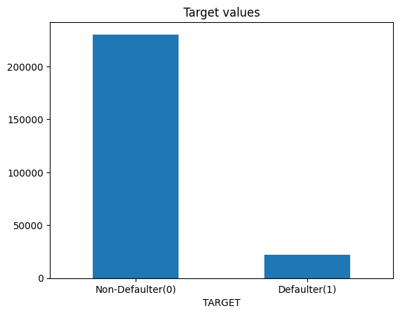

```python
df_app_cleaned.TARGET.value_counts().plot.bar()
plt.title('Target values')
plt.xticks(ticks = [0,1], labels = ['Non-Defaulter(0)', 'Defaulter(1)'], rotation = 0)
```

The target values in this dataset represent whether a client has payment difficulties or not. This is critical because: Target value = 1: The client has experienced payment difficulties (e.g., late payments). This is a high-risk client. Target value = 0: The client has no payment difficulties, making them a low-risk client. By analyzing the distribution of these values, the bank can identify patterns or features associated with defaults.

```python
target_counts = df_app_cleaned.TARGET.value_counts()
```

```python
target_percentage = (target_counts/len(df_app_cleaned))*100
```

```python
target_percentage
```

```
TARGET
0    91.340025
1     8.659975
Name: count, dtype: float64
```

By this we can observe that 8.6 % of total applicants are defaulter i.e they are the people who are not able to make payments on due dates

### Now we will check what is the ratio for males and females who are defaulters and nondefaulters

```python
gender_target_counts = df_app_cleaned.groupby(['CODE_GENDER', 'TARGET']).size()
```

```python
gender_totals = df_app_cleaned.groupby('CODE_GENDER').size()
```

```python
gender_target_percentage = (gender_target_counts / gender_totals) * 100
```

```python
gender_target_percentage
```

```
CODE_GENDER  TARGET
F            0         92.415750
             1          7.584250
M            0         89.559375
             1         10.440625
dtype: float64
```

from this figures we can conclude that the defaulters among females are 7.5 % and males are 10.4 %

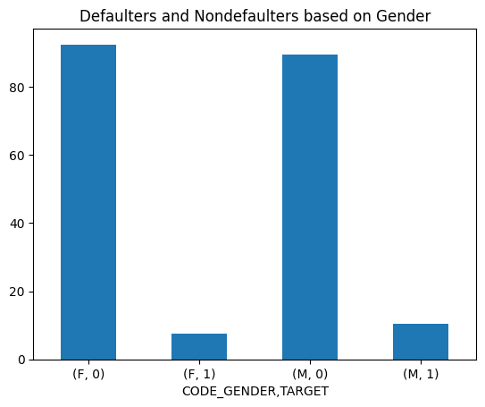

```python
gender_target_percentage.plot.bar()
plt.xticks(rotation=0)
plt.title('Defaulters and Nondefaulters based on Gender')
```

Now we will group the data by target

```python
grouped_data = df_app_cleaned.groupby('TARGET')
```

```python
target0 = grouped_data.get_group(0)
```

```python
target1 = grouped_data.get_group(1)
```

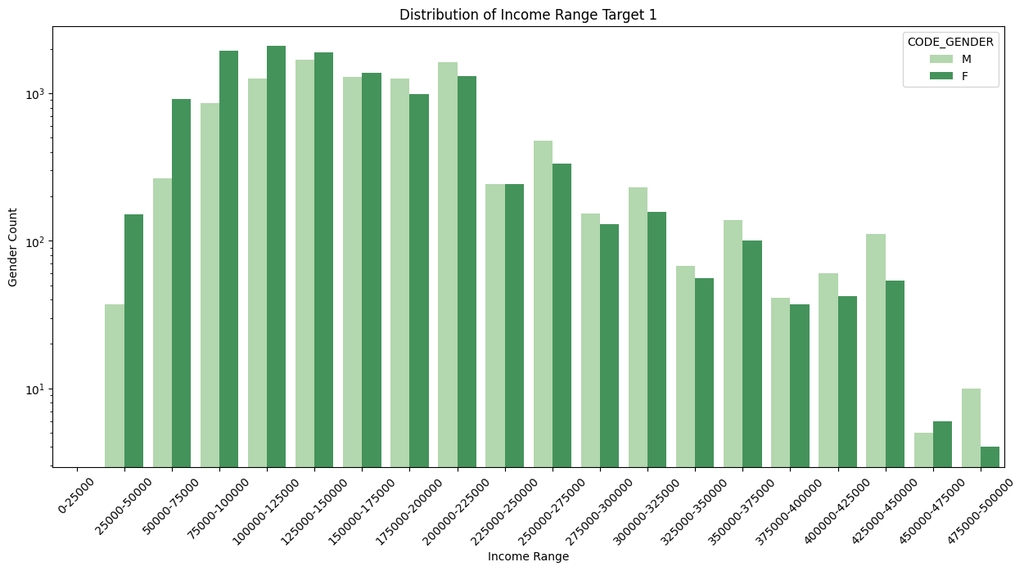

```python
plt.figure(figsize=(15,7))
sns.countplot(data=target1, x='AMT_INCOME_RANGE', hue='CODE_GENDER', palette='Greens')
plt.xticks(rotation=45)
plt.title('Distribution of Income Range Target 1')
plt.xlabel('Income Range')
plt.ylabel('Gender Count')
plt.yscale('log')
```

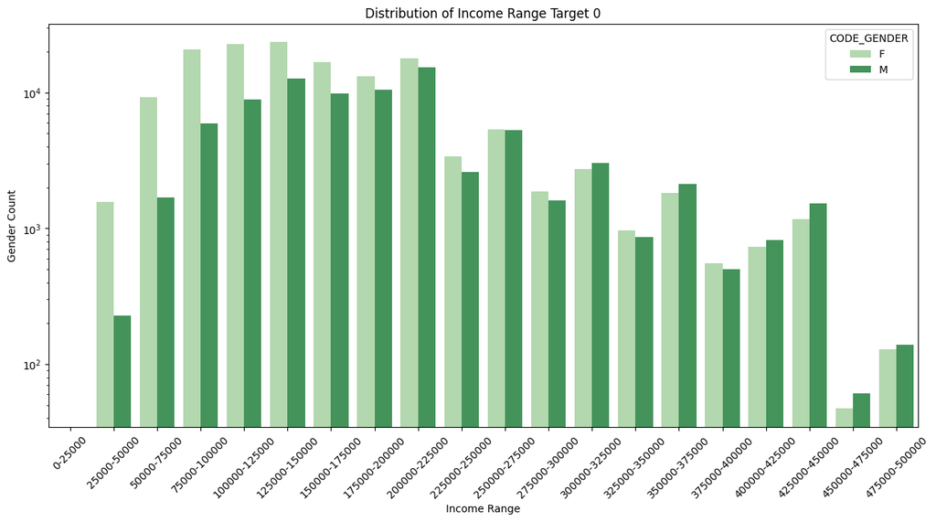

```python
plt.figure(figsize=(15,7))
sns.countplot(data=target0, x='AMT_INCOME_RANGE', hue='CODE_GENDER', palette='Greens')
plt.xticks(rotation=45)
plt.title('Distribution of Income Range Target 0')
plt.xlabel('Income Range')
plt.ylabel('Gender Count')
plt.yscale('log')
```

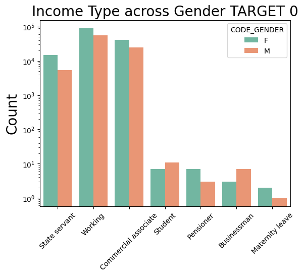

```python
sns.countplot(data=target0, x='NAME_INCOME_TYPE', hue='CODE_GENDER', palette='Set2')
plt.xticks(rotation=45)
plt.title('Income Type across Gender TARGET 0', fontsize=20)
plt.xlabel('Income Type').set_visible(False)
plt.xticks(rotation=45)
plt.ylabel('Count', fontsize=20)
plt.yscale('log')
```

From the above graph we can figure out that how many income types are not defaulters i.e these kind of applicants are repaying the loan and they dont have any repayment issue

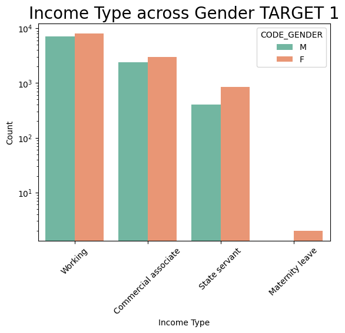

```python
sns.countplot(data=target1, x='NAME_INCOME_TYPE', hue='CODE_GENDER', palette='Set2')
plt.xticks(rotation=45)
plt.title('Income Type across Gender TARGET 1', fontsize=20)
plt.xlabel('Income Type')
plt.xticks(rotation=45)
plt.ylabel('Count')
plt.yscale('log')
```

these are the type of people who are having issue in repaying the loan and they are defaulters

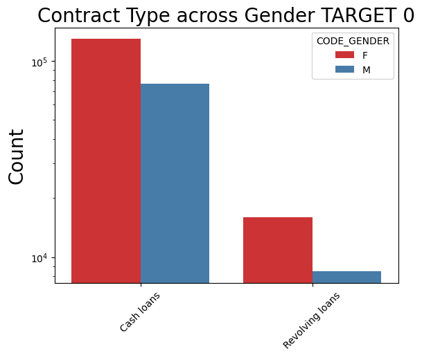

```python
sns.countplot(data=target0, x='NAME_CONTRACT_TYPE', hue='CODE_GENDER', palette='Set1')
plt.xticks(rotation=45)
plt.title('Contract Type across Gender TARGET 0', fontsize=20)
plt.xlabel('Contract Type', fontsize=20).set_visible(False)
plt.ylabel('Count', fontsize=20)
plt.yscale('log')
```

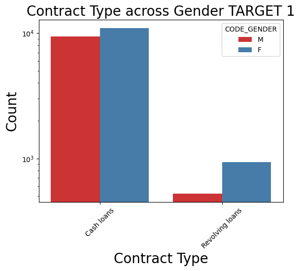

```python
sns.countplot(data=target1, x='NAME_CONTRACT_TYPE', hue='CODE_GENDER', palette='Set1')
plt.xticks(rotation=45)
plt.title('Contract Type across Gender TARGET 1', fontsize=20)
plt.xlabel('Contract Type', fontsize=20)
plt.ylabel('Count', fontsize=20)
plt.yscale('log')
```

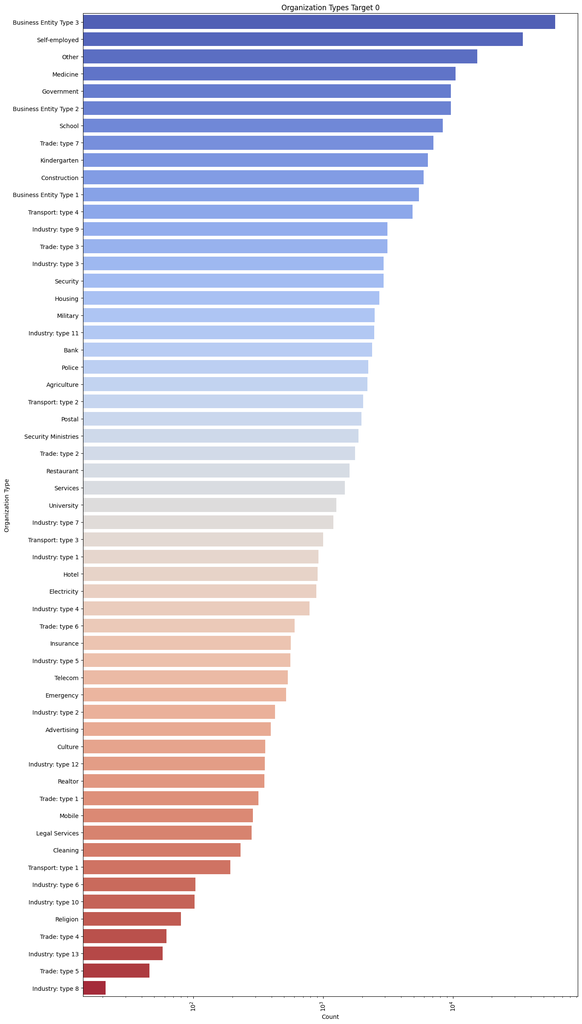

```python
plt.figure(figsize=[15, 30])

sns.countplot(data = target0, y = 'ORGANIZATION_TYPE', order = target0['ORGANIZATION_TYPE'].value_counts().index, palette = 'coolwarm' )
plt.title('Organization Types Target 0')
plt.xticks(rotation=90)
plt.xscale('log')
plt.xlabel('Count')
plt.ylabel('Organization Type')

plt.show()
```

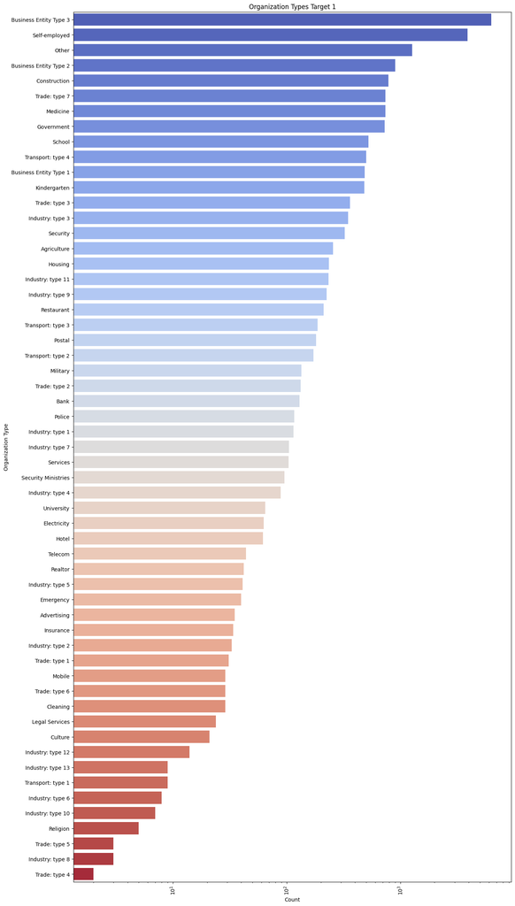

```python
plt.figure(figsize=[15, 30])

sns.countplot(data = target1, y = 'ORGANIZATION_TYPE', order = target1['ORGANIZATION_TYPE'].value_counts().index, palette = 'coolwarm' )
plt.title('Organization Types Target 1')
plt.xticks(rotation=90)
plt.xscale('log')
plt.xlabel('Count')
plt.ylabel('Organization Type')

plt.show()
```

```python
# Listing the relevant columns for finding corelation
correlation_col = ['AMT_INCOME_TOTAL','AMT_CREDIT','AMT_ANNUITY','AMT_GOODS_PRICE']
```

```python
corr_target0 = target0[correlation_col]
corr_target1 = target1[correlation_col]
```

```python
corr_target0.corr()
corr_target1.corr()
```

|  | AMT_INCOME_TOTAL | AMT_CREDIT | AMT_ANNUITY | AMT_GOODS_PRICE |
| --- | --- | --- | --- | --- |
| AMT_INCOME_TOTAL | 1.000000 | 0.036484 | 0.043358 | 0.036086 |
| AMT_CREDIT | 0.036484 | 1.000000 | 0.748708 | 0.982239 |
| AMT_ANNUITY | 0.043358 | 0.748708 | 1.000000 | 0.748651 |
| AMT_GOODS_PRICE | 0.036086 | 0.982239 | 0.748651 | 1.000000 |

```python
corr_matrix = df_app_cleaned[correlation_col].corr()
```

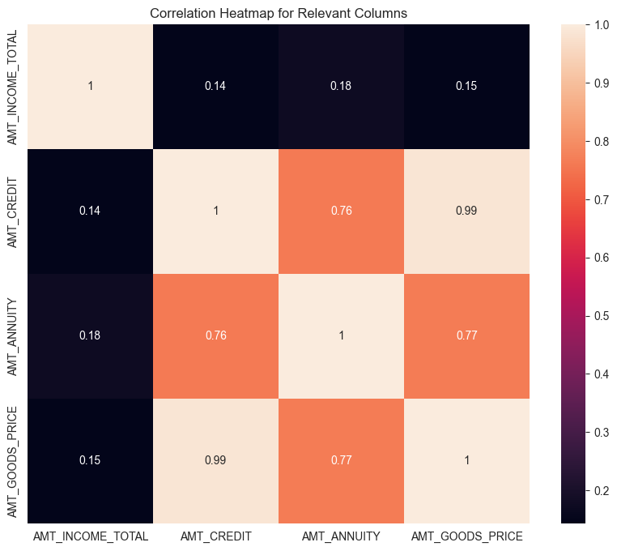

```python
plt.figure(figsize=(10,8))
sns.heatmap(corr_matrix, annot=True)
plt.title('Correlation Heatmap for Relevant Columns')
plt.show()
```

Strong correlations:

AMT_CREDIT and AMT_GOODS_PRICE (0.982), indicating a strong positive relationship.

AMT_CREDIT and AMT_ANNUITY (0.749).

AMT_ANNUITY and AMT_GOODS_PRICE (0.749).

Weak correlations:

AMT_INCOME_TOTAL has weak correlations with all other variables.

# **Bivariate Analysis on Numerical Columns**

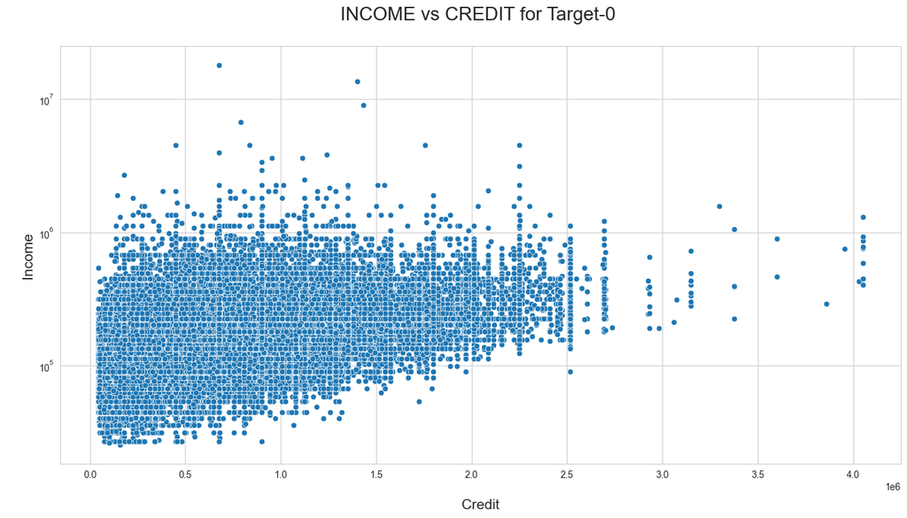

```python
plt.figure(figsize=[16,8])


sns.scatterplot(data = target0, x = target0.AMT_CREDIT, y = target0.AMT_INCOME_TOTAL)
plt.title('INCOME vs CREDIT for Target-0 \n', fontsize=20)
plt.yscale('log')
plt.xlabel('\nCredit', fontsize=15)
plt.ylabel('\nIncome', fontsize=15)
```

from this graph we can observe that the income is low and the loan taken is also low the people with high income tend to have a high credit ability

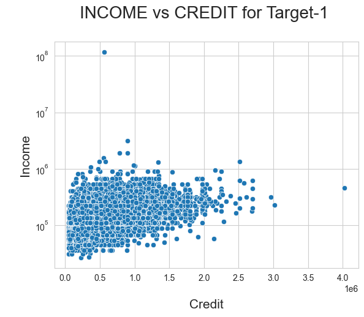

```python
sns.scatterplot(data = target1, x = target1.AMT_CREDIT, y = target1.AMT_INCOME_TOTAL)
plt.title('INCOME vs CREDIT for Target-1 \n', fontsize=20)
plt.yscale('log')
plt.xlabel('\nCredit', fontsize=15)
plt.ylabel('\nIncome', fontsize=15)
```

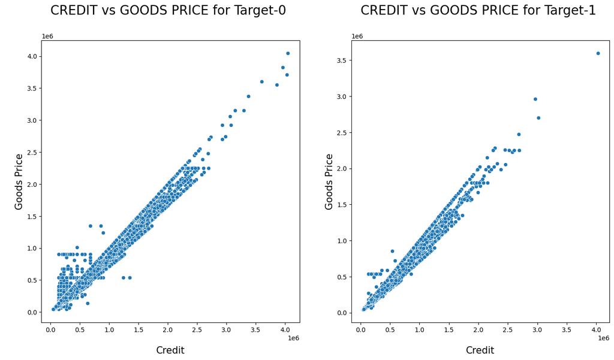

```python
# Plotting scatterplot to find any correlations and to check the trends in the dataset.


plt.figure(figsize=[16,8])

plt.subplot(1,2,1)
sns.scatterplot(x='AMT_CREDIT',y='AMT_GOODS_PRICE',data=target0)
plt.title('CREDIT vs GOODS PRICE for Target-0 \n', fontsize=20)
plt.xlabel('\nCredit', fontsize=15)
plt.ylabel('\nGoods Price', fontsize=15)

plt.subplot(1,2,2)
sns.scatterplot(x='AMT_CREDIT',y='AMT_GOODS_PRICE',data=target1)
plt.title('CREDIT vs GOODS PRICE for Target-1 \n', fontsize=20)
plt.xlabel('\nCredit', fontsize=15)
plt.ylabel('\nGoods Price', fontsize=15)

plt.show()
```

**Univariate Analysis For Target 0**

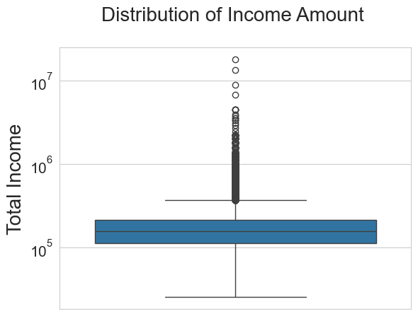

```python
# Distribution of Income Amount,

sns.set_style('whitegrid')

sns.boxplot(data=target0, y='AMT_INCOME_TOTAL')
plt.yscale('log')
plt.yticks(fontsize=15)
plt.ylabel('Total Income', fontsize=20)
plt.title('Distribution of Income Amount \n', fontsize=20)

plt.show()
```

Conclusions:

1. There seems to be an equal distribution of the Income amount of the clients.
2. Also some of the outliers present in the dataset.

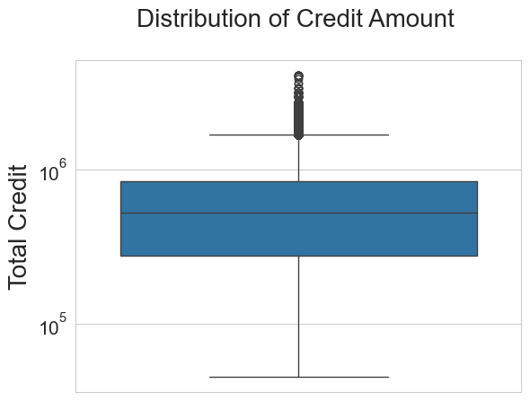

```python
# Distribution of Credit Amount,

sns.set_style('whitegrid')

sns.boxplot(data=target0, y='AMT_CREDIT')
plt.yscale('log')
plt.yticks(fontsize=15)
plt.ylabel('Total Credit', fontsize=20)
plt.title('Distribution of Credit Amount \n', fontsize=20)

plt.show()
```

Conclusion :

1. The first quartile is bigger than the third quartile, that means most of the client credit lies in the first quartile.
2. There seems some outliers in the Credit boxplot.

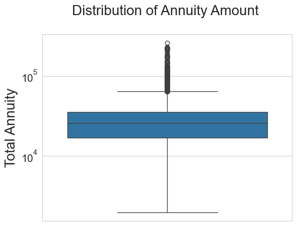

```python
# Distribution of Annuity,

sns.set_style('whitegrid')

sns.boxplot(data=target0, y='AMT_ANNUITY')
plt.yscale('log')
plt.yticks(fontsize=15)
plt.ylabel('Total Annuity', fontsize=20)
plt.title('Distribution of Annuity Amount \n', fontsize=20)

plt.show()
```

Conclusion:

1. The first quartile is bigger than the third quartile.
2. There seems some outliers in the Anuuity boxplot.

**Univariate analysis of Target 1**

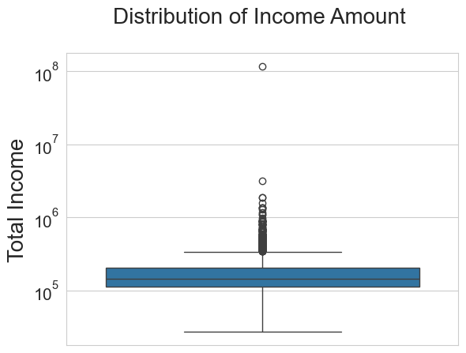

```python
# Distribution of Income Amount,

sns.set_style('whitegrid')

sns.boxplot(data=target1, y='AMT_INCOME_TOTAL')
plt.yscale('log')
plt.yticks(fontsize=15)
plt.ylabel('Total Income', fontsize=20)
plt.title('Distribution of Income Amount \n', fontsize=20)

plt.show()
```

Conclusion :

1. There seems a significant outlier in the Income dataset.
2. Most of the income of the client lies in the third quartile.

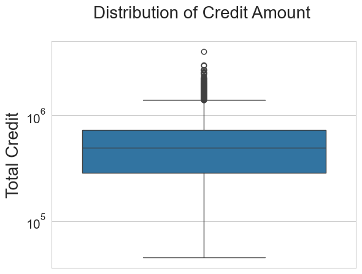

```python
# Distribution of Credit Amount,

sns.set_style('whitegrid')

sns.boxplot(data=target1, y='AMT_CREDIT')
plt.yscale('log')
plt.yticks(fontsize=15)
plt.ylabel('Total Credit', fontsize=20)
plt.title('Distribution of Credit Amount \n', fontsize=20)

plt.show()
```

Conclusions:

1. The first quartile is bigger than the third quartile, that means most of the client credit lies in the first quartile.
2. There seems some outliers in the Credit boxplot.

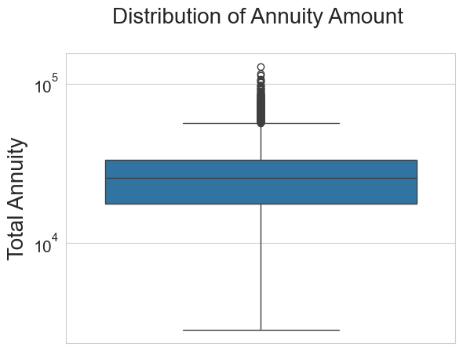

```python
# Distribution of Annuity,

sns.set_style('whitegrid')

sns.boxplot(data=target1, y='AMT_ANNUITY')
plt.yscale('log')
plt.yticks(fontsize=15)
plt.ylabel('Total Annuity', fontsize=20)
plt.title('Distribution of Annuity Amount \n', fontsize=20)

plt.show()
```

Conclusion :

1. The first quartile is bigger than the third quartile.
2. There seems some outliers in the Anuuity boxplot.

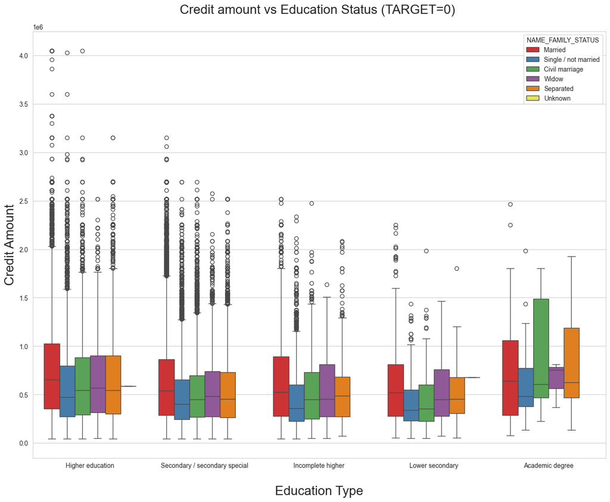

```python
# Box Plotting for the Target = 0, Credit Amount

plt.figure(figsize=[16,12])

sns.boxplot(data =target0, x='NAME_EDUCATION_TYPE',y='AMT_CREDIT', hue ='NAME_FAMILY_STATUS',orient='v', palette='Set1')

plt.xticks(rotation=0)
plt.xlabel('\nEducation Type', fontsize=20)
plt.ylabel('Credit Amount', fontsize=20)
plt.title('Credit amount vs Education Status (TARGET=0) \n', fontsize=20)
plt.show()
```

Conclusion : From the above box plot we can conclude that Family status of 'civil marriage', 'marriage' and 'separated' of Academic degree education are having higher number of credits than others. Also, higher education of family status of 'marriage', 'single' and 'civil marriage' are having more outliers. Civil marriage for Academic degree is having most of the credits in the third quartile.

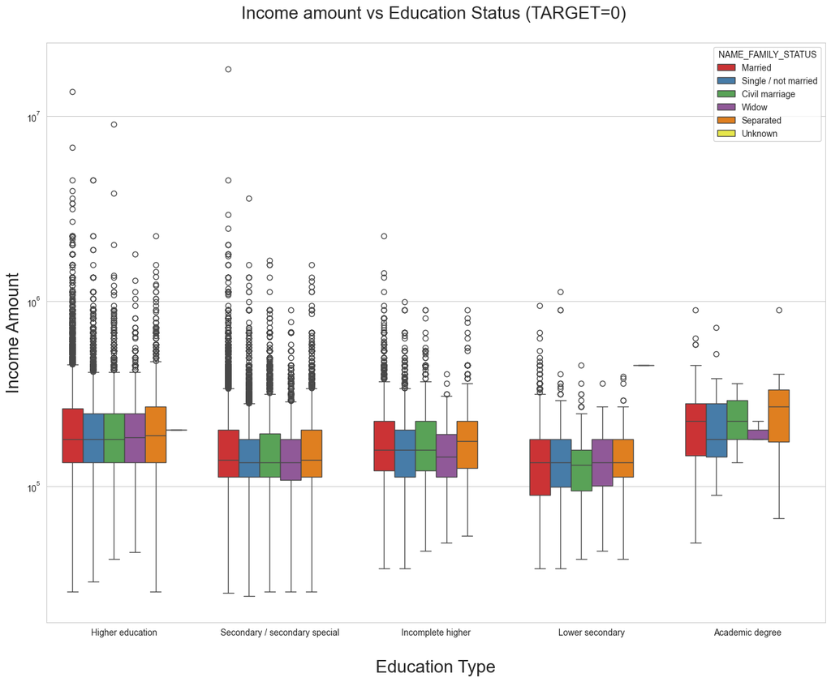

```python
# Box Plotting for the Target = 0, Income Amount

plt.figure(figsize=[16,12])

sns.boxplot(data =target0, x='NAME_EDUCATION_TYPE',y='AMT_INCOME_TOTAL', hue ='NAME_FAMILY_STATUS',orient='v', palette='Set1')

plt.xticks(rotation=0)
plt.xlabel('\nEducation Type', fontsize=20)
plt.ylabel('Income Amount', fontsize=20)
plt.yscale('log')
plt.title('Income amount vs Education Status (TARGET=0) \n', fontsize=20)

plt.show()
```

Conclusion : From above boxplot for Education type 'Higher education' the income amount is mostly equal with family status. It does contain many outliers. Less outlier are having for Academic degree but there income amount is little higher that Higher education. Lower secondary of civil marriage family status are have less income amount than others.

# Target 1

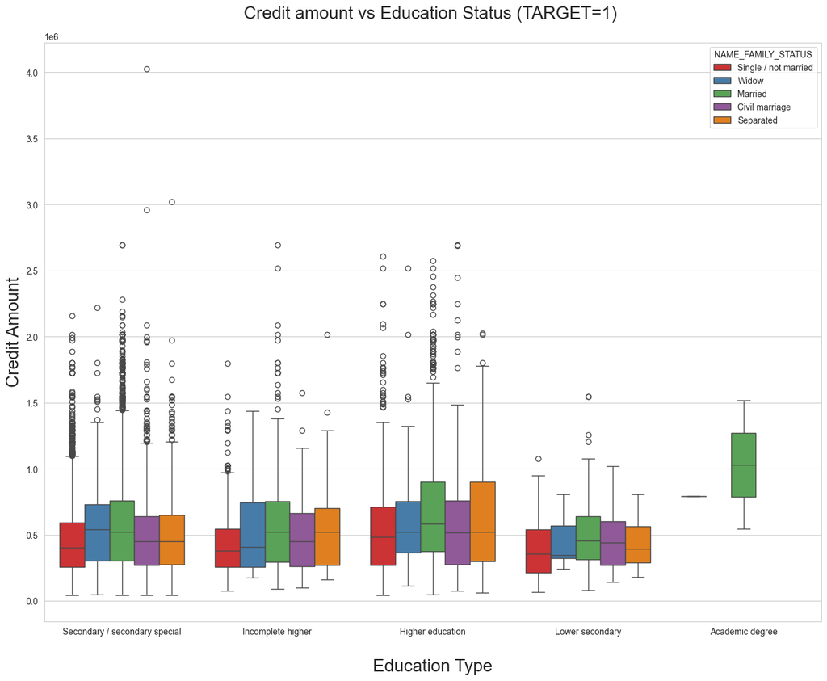

```python
# Box Plotting for the Target = 1, Credit Amount

plt.figure(figsize=[16,12])

sns.boxplot(data =target1, x='NAME_EDUCATION_TYPE', y='AMT_CREDIT', hue ='NAME_FAMILY_STATUS', orient='v', palette='Set1')

plt.xticks(rotation=0)
plt.xlabel('\nEducation Type', fontsize=20)
plt.ylabel('Credit Amount', fontsize=20)
plt.title('Credit amount vs Education Status (TARGET=1) \n', fontsize=20)
plt.show()
```

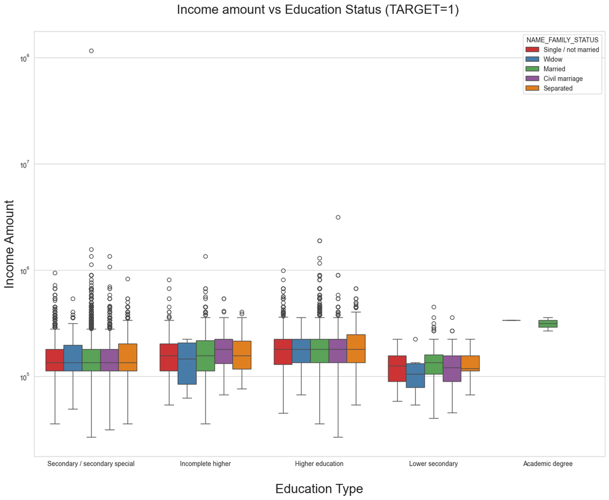

```python
# Box Plotting for the Target = 1, Income Amount

plt.figure(figsize=[16,12])

sns.boxplot(data =target1, x='NAME_EDUCATION_TYPE',y='AMT_INCOME_TOTAL', hue ='NAME_FAMILY_STATUS',orient='v', palette='Set1')

plt.xticks(rotation=0)
plt.xlabel('\nEducation Type', fontsize=20)
plt.ylabel('Income Amount', fontsize=20)
plt.yscale('log')
plt.title('Income amount vs Education Status (TARGET=1) \n', fontsize=20)
plt.show()
```

Conclusion: From above boxplot for Education type 'Higher education' the income amount is mostly equal with family status. Less outlier are having for Academic degree but there income amount is little higher that Higher education. Lower secondary are have less income amount than others.

# **Previous Application DataSet**

```python
# Removing the 'XNA' and 'XAP' column values from the column,

df_prev_cleaned = df_prev_cleaned.drop(df_prev_cleaned[df_prev_cleaned.NAME_CASH_LOAN_PURPOSE=='XNA'].index)
df_prev_cleaned = df_prev_cleaned.drop(df_prev_cleaned[df_prev_cleaned.NAME_CASH_LOAN_PURPOSE=='XAP'].index)
```

```python
# Rechecking the NAME_CASH_LOAN_PURPOSE for the values.

df_prev_cleaned.NAME_CASH_LOAN_PURPOSE.value_counts()
```

```
NAME_CASH_LOAN_PURPOSE
Repairs                             23765
Other                               15608
Urgent needs                         8412
Buying a used car                    2888
Building a house or an annex         2693
Everyday expenses                    2416
Medicine                             2174
Payments on other loans              1931
Education                            1573
Journey                              1239
Purchase of electronic equipment     1061
Buying a new car                     1012
Wedding / gift / holiday              962
Buying a home                         865
Car repairs                           797
Furniture                             749
Buying a holiday home / land          533
Business development                  426
Gasification / water supply           300
Buying a garage                       136
Hobby                                  55
Money for a third person               25
Refusal to name the goal               15
Name: count, dtype: int64
```

# **Merging the two Dataset**

```python
# Merging of the two datasets,

loan_merg = pd.merge(left = df_app_cleaned, right = df_prev_cleaned, how = 'inner', on = 'SK_ID_CURR')
loan_merg.head()
```

|  | SK_ID_CURR | TARGET | NAME_CONTRACT_TYPE_x | CODE_GENDER | FLAG_OWN_CAR | FLAG_OWN_REALTY | CNT_CHILDREN | AMT_INCOME_TOTAL | AMT_CREDIT_x | AMT_ANNUITY | ... | CODE_REJECT_REASON | NAME_CLIENT_TYPE | NAME_GOODS_CATEGORY | NAME_PORTFOLIO | NAME_PRODUCT_TYPE | CHANNEL_TYPE | SELLERPLACE_AREA | NAME_SELLER_INDUSTRY | NAME_YIELD_GROUP | PRODUCT_COMBINATION |
| --- | --- | --- | --- | --- | --- | --- | --- | --- | --- | --- | --- | --- | --- | --- | --- | --- | --- | --- | --- | --- | --- |
| 0 | 100034 | 0 | Revolving loans | M | N | Y | 0 | 90000.0 | 180000.0 | 9000.0 | ... | XAP | New | XNA | Cash | walk-in | Credit and cash offices | -1 | XNA | high | Cash Street: high |
| 1 | 100035 | 0 | Cash loans | F | N | Y | 0 | 292500.0 | 665892.0 | 24592.5 | ... | HC | Repeater | XNA | Cash | walk-in | Credit and cash offices | -1 | XNA | low_action | Cash Street: low |
| 2 | 100039 | 0 | Cash loans | M | Y | N | 1 | 360000.0 | 733315.5 | 39069.0 | ... | XAP | Refreshed | XNA | Cash | walk-in | Channel of corporate sales | -1 | XNA | low_normal | Cash Street: low |
| 3 | 100046 | 0 | Revolving loans | M | Y | Y | 0 | 180000.0 | 540000.0 | 27000.0 | ... | XAP | New | XNA | Cash | walk-in | Credit and cash offices | -1 | XNA | low_normal | Cash Street: low |
| 4 | 100046 | 0 | Revolving loans | M | Y | Y | 0 | 180000.0 | 540000.0 | 27000.0 | ... | LIMIT | Repeater | XNA | Cash | walk-in | Credit and cash offices | -1 | XNA | low_normal | Cash Street: low |

5 rows × 66 columns

```python
# Renaming the columns in the loan_merg datasets,

loan_merg = loan_merg.rename({'NAME_CONTRACT_TYPE_' : 'NAME_CONTRACT_TYPE','AMT_CREDIT_':'AMT_CREDIT','AMT_ANNUITY_':'AMT_ANNUITY',
                         'WEEKDAY_APPR_PROCESS_START_' : 'WEEKDAY_APPR_PROCESS_START',
                         'HOUR_APPR_PROCESS_START_':'HOUR_APPR_PROCESS_START','NAME_CONTRACT_TYPEx':'NAME_CONTRACT_TYPE_PREV',
                         'AMT_CREDITx':'AMT_CREDIT_PREV','AMT_ANNUITYx':'AMT_ANNUITY_PREV',
                         'WEEKDAY_APPR_PROCESS_STARTx':'WEEKDAY_APPR_PROCESS_START_PREV',
                         'HOUR_APPR_PROCESS_STARTx':'HOUR_APPR_PROCESS_START_PREV'}, axis=1)
```

```python
# Removing the unwanted columns from the dataset for the ease of analysis

loan_merg.drop(['SK_ID_CURR','REG_REGION_NOT_LIVE_REGION',
              'REG_REGION_NOT_WORK_REGION','LIVE_REGION_NOT_WORK_REGION', 'REG_CITY_NOT_LIVE_CITY',
              'REG_CITY_NOT_WORK_CITY', 'LIVE_CITY_NOT_WORK_CITY', 'FLAG_LAST_APPL_PER_CONTRACT','NFLAG_LAST_APPL_IN_DAY'],axis=1,inplace=True)
```

**Preforming the Univariate analysis**

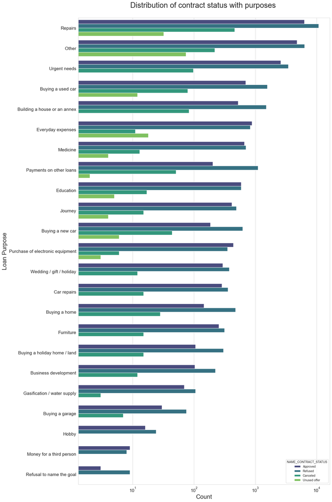

```python
# Plotting for the Contract Status,

plt.figure(figsize=[15,28])

sns.countplot(data = loan_merg, y= 'NAME_CASH_LOAN_PURPOSE',
                   order=loan_merg['NAME_CASH_LOAN_PURPOSE'].value_counts().index,hue = 'NAME_CONTRACT_STATUS',palette='viridis')

plt.title('Distribution of contract status with purposes \n', fontsize=25)
plt.xticks(fontsize=15)
plt.yticks(fontsize=15)
plt.xlabel('Count', fontsize=20)
plt.ylabel('Loan Purpose', fontsize=20)
plt.xscale('log')

plt.show()
```

**Performing the bivariate analysis**

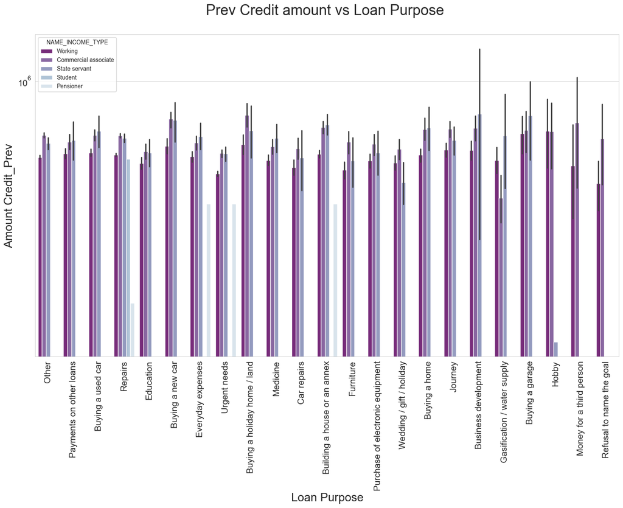

```python
# Plotting for Credit amount in logarithmic scale

plt.figure(figsize=(18,10))

sns.barplot(data = loan_merg, x='NAME_CASH_LOAN_PURPOSE', hue='NAME_INCOME_TYPE', y='AMT_CREDIT_x', orient='v', palette='BuPu_r')
plt.xticks(rotation=90)
plt.ylabel('Amount Credit_Prev', fontsize=20)
plt.xlabel('Loan Purpose', fontsize=20)
plt.yscale('log')
plt.xticks(fontsize=15)
plt.yticks(fontsize=15)
plt.title('Prev Credit amount vs Loan Purpose \n', fontsize=25)

plt.show()
```

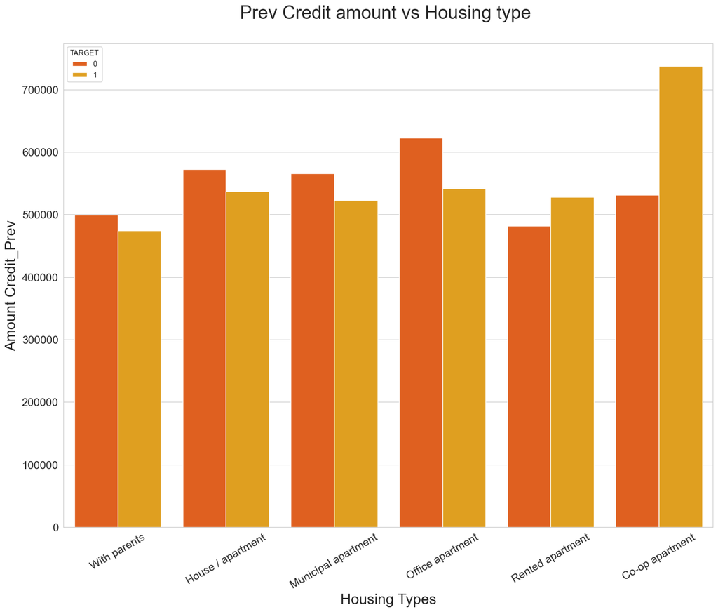

```python
# Plotting for Credit amount prev vs Housing type,

plt.figure(figsize=(16,12))
plt.xticks(rotation=30)
sns.barplot(data =loan_merg, y='AMT_CREDIT_x',hue='TARGET',x='NAME_HOUSING_TYPE', palette='autumn', ci = None)
plt.title('Prev Credit amount vs Housing type \n', fontsize=25)
plt.ylabel('Amount Credit_Prev', fontsize=20)
plt.xlabel('Housing Types', fontsize=20)
plt.xticks(fontsize=15)
plt.yticks(fontsize=15)

plt.show()
```

# **Conclusion on my EDA analysis**

Loans for repairs and other relevant purposes should be increased as it contributes towards our developement. while assigning loan the credit ability should be considered banks should give loans to the non defaulters as they pay loan on time and strict check should be put so that the defaulters will be reduced as the ratio of gender shows the females are less defaulters the approval of loan for females should be more as compared to males bank should assign loans to municipal apartments and office appartment as there repayment is good and should reduce giving loans to Co-op apartment